# 2020 - 2021 Summer Term Project

# END305E: Data Analytics for Business

# 23 August 2021

# Selin Saki

### Introduction

This notebook was published on Github [@Pinnatisect](https://github.com/Pinnatisect).  
Please use the data files attached in the [repository](https://github.com/Pinnatisect/END305E-Data-Analytics-for-Business).

### OLS Regression

Variables are defined as follows:

- mpg - miles per gallon
- cyl - # of cylinders
- disp - displacement, in cubic inches
- hp - horsepower
- drat - driveshaft ratio
- wt - weight
- qsec - 1/4 mile time; a measure of acceleration
- vs - 'V' or straight - engine shape
- am - transmission; auto or manual
- gear - # of gears
- carb - # of carburetors

```python
from warnings import filterwarnings
filterwarnings('ignore')
```

```python
import pandas as pd
import numpy as np
```

```python
data = pd.read_csv("mtcars.csv")
```

```python
data.head()
```

|  | model | mpg | cyl | disp | hp | drat | wt | qsec | vs | am | gear | carb |
| --- | --- | --- | --- | --- | --- | --- | --- | --- | --- | --- | --- | --- |
| 0 | Mazda RX4 | 21.0 | 6 | 160.0 | 110 | 3.90 | 2.620 | 16.46 | 0 | 1 | 4 | 4 |
| 1 | Mazda RX4 Wag | 21.0 | 6 | 160.0 | 110 | 3.90 | 2.875 | 17.02 | 0 | 1 | 4 | 4 |
| 2 | Datsun 710 | 22.8 | 4 | 108.0 | 93 | 3.85 | 2.320 | 18.61 | 1 | 1 | 4 | 1 |
| 3 | Hornet 4 Drive | 21.4 | 6 | 258.0 | 110 | 3.08 | 3.215 | 19.44 | 1 | 0 | 3 | 1 |
| 4 | Hornet Sportabout | 18.7 | 8 | 360.0 | 175 | 3.15 | 3.440 | 17.02 | 0 | 0 | 3 | 2 |

```python
import statsmodels.api as sm
X = data.loc[:,["cyl","disp","hp","drat","wt","qsec","vs","am", "gear", "carb",]]
```

```python
X = sm.add_constant(X)
```

```python
y = data["mpg"]
lm = sm.OLS(y,X)
model = lm.fit()
model.summary()
```

OLS Regression Results

| Dep. Variable: | mpg | R-squared: | 0.869 |
| --- | --- | --- | --- |
| Model: | OLS | Adj. R-squared: | 0.807 |
| Method: | Least Squares | F-statistic: | 13.93 |
| Date: | Mon, 23 Aug 2021 | Prob (F-statistic): | 3.79e-07 |
| Time: | 16:24:47 | Log-Likelihood: | -69.855 |
| No. Observations: | 32 | AIC: | 161.7 |
| Df Residuals: | 21 | BIC: | 177.8 |
| Df Model: | 10 |  |  |
| Covariance Type: | nonrobust |  |  |

|  | coef | std err | t | P>\|t\| | [0.025 | 0.975] |
| --- | --- | --- | --- | --- | --- | --- |
| const | 12.3034 | 18.718 | 0.657 | 0.518 | -26.623 | 51.229 |
| cyl | -0.1114 | 1.045 | -0.107 | 0.916 | -2.285 | 2.062 |
| disp | 0.0133 | 0.018 | 0.747 | 0.463 | -0.024 | 0.050 |
| hp | -0.0215 | 0.022 | -0.987 | 0.335 | -0.067 | 0.024 |
| drat | 0.7871 | 1.635 | 0.481 | 0.635 | -2.614 | 4.188 |
| wt | -3.7153 | 1.894 | -1.961 | 0.063 | -7.655 | 0.224 |
| qsec | 0.8210 | 0.731 | 1.123 | 0.274 | -0.699 | 2.341 |
| vs | 0.3178 | 2.105 | 0.151 | 0.881 | -4.059 | 4.694 |
| am | 2.5202 | 2.057 | 1.225 | 0.234 | -1.757 | 6.797 |
| gear | 0.6554 | 1.493 | 0.439 | 0.665 | -2.450 | 3.761 |
| carb | -0.1994 | 0.829 | -0.241 | 0.812 | -1.923 | 1.524 |

| Omnibus: | 1.907 | Durbin-Watson: | 1.861 |
| --- | --- | --- | --- |
| Prob(Omnibus): | 0.385 | Jarque-Bera (JB): | 1.747 |
| Skew: | 0.521 | Prob(JB): | 0.418 |
| Kurtosis: | 2.526 | Cond. No. | 1.22e+04 |

Notes:  
[1] Standard Errors assume that the covariance matrix of the errors is correctly specified.  
[2] The condition number is large, 1.22e+04. This might indicate that there are  
strong multicollinearity or other numerical problems.

#### Comment:

- When we try to fit the model using all of the variables, it gives a high R-squared value. The model is able to explain 86.9% of the variation.
- F-statistic significance << 0.05, which indicates the values are close to the fitting line.
- However, by checking P>|t| values, all of the variables are insignificant at p = 0.05 significance level. (Bigger than 0.05, which incicates fail to reject null hypothesis H0: beta = 0)

```python
from statsmodels.stats.outliers_influence import variance_inflation_factor
vif_data = pd.DataFrame()
vif_data["feature"] = X.columns
vif_data["VIF"] = [variance_inflation_factor(X.values, i)
                          for i in range(len(X.columns))]

print(vif_data)
```

```
   feature          VIF
0    const  1596.273030
1      cyl    15.373833
2     disp    21.620241
3       hp     9.832037
4     drat     3.374620
5       wt    15.164887
6     qsec     7.527958
7       vs     4.965873
8       am     4.648487
9     gear     5.357452
10    carb     7.908747
```

#### Comment:

Variance Inflation Factor (VIF) shows that there is a multicollinearity prolem, since most of the VIF values are bigger than or equal to 5.  
We will deal with this problem in a bit. Lets check heteroskedasticity of the values.

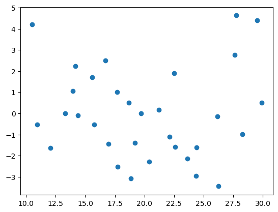

```python
import matplotlib.pyplot as plt
x=model.fittedvalues
y=model.resid
plt.scatter(x, y)
plt.show()
```

#### Comment:

It seems that the variation is not a big problem for the error term. Let's use the White Test.

```python
from statsmodels.stats.diagnostic import het_white
```

```python
white_test = het_white(model.resid,  model.model.exog)
```

```python
labels=("LM Statistic","LM-Test p-value", "F-Statistic", "F-Test p-value")
print(labels, white_test)
```

```
('LM Statistic', 'LM-Test p-value', 'F-Statistic', 'F-Test p-value') (32.0, 0.41674402994554294, nan, nan)
```

#### Comment:

- transform highly correlated variables
- drop one of the collinear variables
- use Lasso or Ridge Regression
- collect more data etc.

Since we cannot collect more data at this point, we should connsider other methods.  
Let's first transform the model from level - level to log - level by taking the logarithm of the dependent variable and see how it works.

```python
y_2 = np.log(data["mpg"])
X= sm.add_constant(X)
lm = sm.OLS(y_2, X)
model = lm.fit()
model.summary()
```

OLS Regression Results

| Dep. Variable: | mpg | R-squared: | 0.890 |
| --- | --- | --- | --- |
| Model: | OLS | Adj. R-squared: | 0.837 |
| Method: | Least Squares | F-statistic: | 16.91 |
| Date: | Mon, 23 Aug 2021 | Prob (F-statistic): | 6.89e-08 |
| Time: | 16:24:48 | Log-Likelihood: | 29.118 |
| No. Observations: | 32 | AIC: | -36.24 |
| Df Residuals: | 21 | BIC: | -20.11 |
| Df Model: | 10 |  |  |
| Covariance Type: | nonrobust |  |  |

|  | coef | std err | t | P>\|t\| | [0.025 | 0.975] |
| --- | --- | --- | --- | --- | --- | --- |
| const | 2.7756 | 0.849 | 3.268 | 0.004 | 1.010 | 4.542 |
| cyl | 0.0077 | 0.047 | 0.161 | 0.873 | -0.091 | 0.106 |
| disp | 4.989e-05 | 0.001 | 0.062 | 0.951 | -0.002 | 0.002 |
| hp | -0.0009 | 0.001 | -0.908 | 0.374 | -0.003 | 0.001 |
| drat | 0.0222 | 0.074 | 0.299 | 0.768 | -0.132 | 0.177 |
| wt | -0.1723 | 0.086 | -2.005 | 0.058 | -0.351 | 0.006 |
| qsec | 0.0308 | 0.033 | 0.928 | 0.364 | -0.038 | 0.100 |
| vs | -0.0029 | 0.095 | -0.030 | 0.976 | -0.201 | 0.196 |
| am | 0.0474 | 0.093 | 0.508 | 0.617 | -0.147 | 0.241 |
| gear | 0.0593 | 0.068 | 0.875 | 0.392 | -0.082 | 0.200 |
| carb | -0.0201 | 0.038 | -0.535 | 0.598 | -0.098 | 0.058 |

| Omnibus: | 2.400 | Durbin-Watson: | 1.932 |
| --- | --- | --- | --- |
| Prob(Omnibus): | 0.301 | Jarque-Bera (JB): | 2.013 |
| Skew: | 0.602 | Prob(JB): | 0.365 |
| Kurtosis: | 2.751 | Cond. No. | 1.22e+04 |

Notes:  
[1] Standard Errors assume that the covariance matrix of the errors is correctly specified.  
[2] The condition number is large, 1.22e+04. This might indicate that there are  
strong multicollinearity or other numerical problems.

#### Comment:

It seems that using log-level transformation had no impact. P>|t| values still indicate that variables are insignificant.

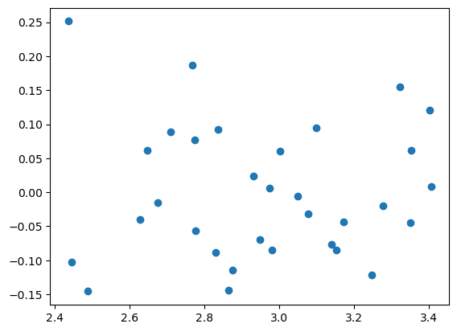

```python
x=model.fittedvalues
y_2=model.resid
plt.scatter(x, y_2)
plt.show()
```

#### Comment:

As seen from the plot, transformation did not change anything. Instead, we can use Lasso or Ridge Regression to get rid of multicollinearity problem.

### Lasso Regression

```python
from sklearn.linear_model import Lasso
X= sm.add_constant(X)
lasso_model = Lasso(alpha = 0.01).fit(X, y)               #model for lambda = 0.01
```

```python
lasso_model
lasso_model.coef_
```

```
array([ 0.,  0.,  0.,  0., -0.,  0., -0., -0., -0., -0.,  0.])
```

#### Comment:

Alpha or lambda parameter was chosen as 0.01 for the penalty term. Since we know that all variables are insignificant together in the model, all of the beta coefficients are almost equal to zero or zero. Let's find the optimum alpha or lambda parameter.

```python
from sklearn.linear_model import LassoCV
lasso_cv_model = LassoCV(alphas = None, cv = 10,
                         max_iter = 100000,
                         normalize = True, tol = 1000)
lasso_cv_model.fit(X,y)
lasso_cv_model.alpha_
```

[output not shown]

```python
lasso_tuned = Lasso(alpha = lasso_cv_model.alpha_)
lasso_tuned.fit(X, y)
y_pred = lasso_tuned.predict(X)
```

```python
from sklearn.metrics import mean_squared_error
np.sqrt(mean_squared_error(y, y_pred))
```

```
2.1469049671609435
```

```python
from sklearn.linear_model import Lasso
lasso_model = Lasso(alpha = 1.987299214079029e-14).fit(X, y)
```

```python
lasso_model
lasso_model.coef_
```

```
array([ 0.00000000e+00, -0.00000000e+00,  1.09904118e-15,  6.86446883e-16,
        0.00000000e+00, -0.00000000e+00, -0.00000000e+00,  0.00000000e+00,
        0.00000000e+00,  0.00000000e+00, -0.00000000e+00])
```

### Ridge Regression

```python
from sklearn.linear_model import Ridge
ridge_model = Ridge(alpha = 0.1).fit(X, y)
ridge_model.coef_
```

```
array([ 0.00000000e+00,  2.81435519e-15,  1.12598260e-15,  7.44045476e-16,
        1.01494701e-14,  9.85241990e-16,  1.12595460e-15, -2.37775702e-17,
       -1.62528932e-15,  1.03514447e-14, -5.35169777e-15])
```

```python
from sklearn.linear_model import RidgeCV
lambdas = 10**np.linspace(10,-2,100)*0.5
```

```python
print(lambdas)
```

```
[5.00000000e+09 3.78231664e+09 2.86118383e+09 2.16438064e+09
 1.63727458e+09 1.23853818e+09 9.36908711e+08 7.08737081e+08
 5.36133611e+08 4.05565415e+08 3.06795364e+08 2.32079442e+08
 1.75559587e+08 1.32804389e+08 1.00461650e+08 7.59955541e+07
 5.74878498e+07 4.34874501e+07 3.28966612e+07 2.48851178e+07
 1.88246790e+07 1.42401793e+07 1.07721735e+07 8.14875417e+06
 6.16423370e+06 4.66301673e+06 3.52740116e+06 2.66834962e+06
 2.01850863e+06 1.52692775e+06 1.15506485e+06 8.73764200e+05
 6.60970574e+05 5.00000000e+05 3.78231664e+05 2.86118383e+05
 2.16438064e+05 1.63727458e+05 1.23853818e+05 9.36908711e+04
 7.08737081e+04 5.36133611e+04 4.05565415e+04 3.06795364e+04
 2.32079442e+04 1.75559587e+04 1.32804389e+04 1.00461650e+04
 7.59955541e+03 5.74878498e+03 4.34874501e+03 3.28966612e+03
 2.48851178e+03 1.88246790e+03 1.42401793e+03 1.07721735e+03
 8.14875417e+02 6.16423370e+02 4.66301673e+02 3.52740116e+02
 2.66834962e+02 2.01850863e+02 1.52692775e+02 1.15506485e+02
 8.73764200e+01 6.60970574e+01 5.00000000e+01 3.78231664e+01
 2.86118383e+01 2.16438064e+01 1.63727458e+01 1.23853818e+01
 9.36908711e+00 7.08737081e+00 5.36133611e+00 4.05565415e+00
 3.06795364e+00 2.32079442e+00 1.75559587e+00 1.32804389e+00
 1.00461650e+00 7.59955541e-01 5.74878498e-01 4.34874501e-01
 3.28966612e-01 2.48851178e-01 1.88246790e-01 1.42401793e-01
 1.07721735e-01 8.14875417e-02 6.16423370e-02 4.66301673e-02
 3.52740116e-02 2.66834962e-02 2.01850863e-02 1.52692775e-02
 1.15506485e-02 8.73764200e-03 6.60970574e-03 5.00000000e-03]
```

```python
ridge_model = Ridge()
coeffs = []
```

```python
for i in lambdas:
    ridge_model.set_params(alpha = i)
    ridge_model.fit(X, y)
    coeffs.append(ridge_model.coef_)
```

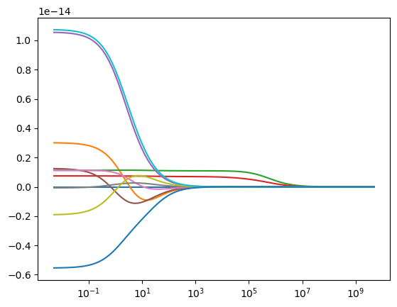

```python
ax = plt.gca()
ax.plot(lambdas, coeffs)
ax.set_xscale('log')
plt.show()
```

```python
from sklearn.linear_model import RidgeCV
ridge_cv=RidgeCV(alphas=lambdas, scoring="neg_mean_squared_error", normalize=True)
```

```python
ridge_cv.fit(X,y)
```

```
RidgeCV(alphas=array([5.00000000e+09, 3.78231664e+09, 2.86118383e+09, 2.16438064e+09,
       1.63727458e+09, 1.23853818e+09, 9.36908711e+08, 7.08737081e+08,
       5.36133611e+08, 4.05565415e+08, 3.06795364e+08, 2.32079442e+08,
       1.75559587e+08, 1.32804389e+08, 1.00461650e+08, 7.59955541e+07,
       5.74878498e+07, 4.34874501e+07, 3.28966612e+07, 2.48851178e+07,
       1.88246790e+07, 1.42401793e+0...
       1.00461650e+00, 7.59955541e-01, 5.74878498e-01, 4.34874501e-01,
       3.28966612e-01, 2.48851178e-01, 1.88246790e-01, 1.42401793e-01,
       1.07721735e-01, 8.14875417e-02, 6.16423370e-02, 4.66301673e-02,
       3.52740116e-02, 2.66834962e-02, 2.01850863e-02, 1.52692775e-02,
       1.15506485e-02, 8.73764200e-03, 6.60970574e-03, 5.00000000e-03]),
        normalize=True, scoring='neg_mean_squared_error')
```

```python
ridge_cv.alpha_
```

```
5000000000.0
```

```python
ridge_model = Ridge(alpha = ridge_cv.alpha_).fit(X, y)           # coefficients with optimum alfa
ridge_model.coef_
```

```
array([ 0.00000000e+00,  1.78538724e-21,  1.33225534e-19,  6.59308901e-20,
       -3.81160566e-22,  9.13650917e-22, -1.03088265e-21, -4.07449371e-22,
       -2.78587960e-22, -3.61088775e-22,  8.81328963e-22])
```

#### Comment:

Unfortunately, since the OLS regression coefficient values were small at the first hand, Ridge Regression also gives a bad output, just as Lasso. Our model was not complex and it did not include a lot of independent variables. So, let's use Backward Stepwise Selection and see whether we can drop some variables which cause the multicollinearity problem.

### Backward Stepwise Selection

Let's check the OLS output again and see which significance levels are problematic.

```python
model.summary()
```

OLS Regression Results

| Dep. Variable: | mpg | R-squared: | 0.890 |
| --- | --- | --- | --- |
| Model: | OLS | Adj. R-squared: | 0.837 |
| Method: | Least Squares | F-statistic: | 16.91 |
| Date: | Mon, 23 Aug 2021 | Prob (F-statistic): | 6.89e-08 |
| Time: | 16:24:51 | Log-Likelihood: | 29.118 |
| No. Observations: | 32 | AIC: | -36.24 |
| Df Residuals: | 21 | BIC: | -20.11 |
| Df Model: | 10 |  |  |
| Covariance Type: | nonrobust |  |  |

|  | coef | std err | t | P>\|t\| | [0.025 | 0.975] |
| --- | --- | --- | --- | --- | --- | --- |
| const | 2.7756 | 0.849 | 3.268 | 0.004 | 1.010 | 4.542 |
| cyl | 0.0077 | 0.047 | 0.161 | 0.873 | -0.091 | 0.106 |
| disp | 4.989e-05 | 0.001 | 0.062 | 0.951 | -0.002 | 0.002 |
| hp | -0.0009 | 0.001 | -0.908 | 0.374 | -0.003 | 0.001 |
| drat | 0.0222 | 0.074 | 0.299 | 0.768 | -0.132 | 0.177 |
| wt | -0.1723 | 0.086 | -2.005 | 0.058 | -0.351 | 0.006 |
| qsec | 0.0308 | 0.033 | 0.928 | 0.364 | -0.038 | 0.100 |
| vs | -0.0029 | 0.095 | -0.030 | 0.976 | -0.201 | 0.196 |
| am | 0.0474 | 0.093 | 0.508 | 0.617 | -0.147 | 0.241 |
| gear | 0.0593 | 0.068 | 0.875 | 0.392 | -0.082 | 0.200 |
| carb | -0.0201 | 0.038 | -0.535 | 0.598 | -0.098 | 0.058 |

| Omnibus: | 2.400 | Durbin-Watson: | 1.932 |
| --- | --- | --- | --- |
| Prob(Omnibus): | 0.301 | Jarque-Bera (JB): | 2.013 |
| Skew: | 0.602 | Prob(JB): | 0.365 |
| Kurtosis: | 2.751 | Cond. No. | 1.22e+04 |

Notes:  
[1] Standard Errors assume that the covariance matrix of the errors is correctly specified.  
[2] The condition number is large, 1.22e+04. This might indicate that there are  
strong multicollinearity or other numerical problems.

#### Comment:

```python
X_new = data.loc[:,["disp","hp","drat","wt","qsec","vs","am", "gear", "carb",]]
```

```python
y = data["mpg"]
lm = sm.OLS(y,X_new)
model = lm.fit()
model.summary()
```

OLS Regression Results

| Dep. Variable: | mpg | R-squared (uncentered): | 0.989 |
| --- | --- | --- | --- |
| Model: | OLS | Adj. R-squared (uncentered): | 0.985 |
| Method: | Least Squares | F-statistic: | 233.6 |
| Date: | Mon, 23 Aug 2021 | Prob (F-statistic): | 1.97e-20 |
| Time: | 16:24:51 | Log-Likelihood: | -70.334 |
| No. Observations: | 32 | AIC: | 158.7 |
| Df Residuals: | 23 | BIC: | 171.9 |
| Df Model: | 9 |  |  |
| Covariance Type: | nonrobust |  |  |

|  | coef | std err | t | P>\|t\| | [0.025 | 0.975] |
| --- | --- | --- | --- | --- | --- | --- |
| disp | 0.0166 | 0.016 | 1.034 | 0.312 | -0.017 | 0.050 |
| hp | -0.0175 | 0.020 | -0.873 | 0.391 | -0.059 | 0.024 |
| drat | 1.2504 | 1.437 | 0.870 | 0.393 | -1.723 | 4.224 |
| wt | -4.0269 | 1.779 | -2.263 | 0.033 | -7.707 | -0.346 |
| qsec | 1.3009 | 0.386 | 3.370 | 0.003 | 0.502 | 2.100 |
| vs | -0.3049 | 1.736 | -0.176 | 0.862 | -3.896 | 3.286 |
| am | 2.6991 | 1.920 | 1.406 | 0.173 | -1.273 | 6.671 |
| gear | 0.9818 | 1.314 | 0.747 | 0.463 | -1.737 | 3.701 |
| carb | -0.1873 | 0.782 | -0.240 | 0.813 | -1.804 | 1.430 |

| Omnibus: | 1.433 | Durbin-Watson: | 2.050 |
| --- | --- | --- | --- |
| Prob(Omnibus): | 0.488 | Jarque-Bera (JB): | 1.306 |
| Skew: | 0.362 | Prob(JB): | 0.520 |
| Kurtosis: | 2.325 | Cond. No. | 1.46e+03 |

Notes:  
[1] R² is computed without centering (uncentered) since the model does not contain a constant.  
[2] Standard Errors assume that the covariance matrix of the errors is correctly specified.  
[3] The condition number is large, 1.46e+03. This might indicate that there are  
strong multicollinearity or other numerical problems.

#### Comment:

It seems better now, let's delete the second variable which has the largest P>|t| value, "vs".

```python
X_new = data.loc[:,["disp","hp","drat","wt","qsec","am", "gear", "carb",]]
```

```python
y = data["mpg"]
lm = sm.OLS(y,X_new)
model = lm.fit()
model.summary()
```

OLS Regression Results

| Dep. Variable: | mpg | R-squared (uncentered): | 0.989 |
| --- | --- | --- | --- |
| Model: | OLS | Adj. R-squared (uncentered): | 0.986 |
| Method: | Least Squares | F-statistic: | 273.8 |
| Date: | Mon, 23 Aug 2021 | Prob (F-statistic): | 1.16e-21 |
| Time: | 16:24:51 | Log-Likelihood: | -70.355 |
| No. Observations: | 32 | AIC: | 156.7 |
| Df Residuals: | 24 | BIC: | 168.4 |
| Df Model: | 8 |  |  |
| Covariance Type: | nonrobust |  |  |

|  | coef | std err | t | P>\|t\| | [0.025 | 0.975] |
| --- | --- | --- | --- | --- | --- | --- |
| disp | 0.0177 | 0.015 | 1.212 | 0.237 | -0.012 | 0.048 |
| hp | -0.0180 | 0.019 | -0.923 | 0.365 | -0.058 | 0.022 |
| drat | 1.2555 | 1.408 | 0.892 | 0.381 | -1.650 | 4.161 |
| wt | -4.0438 | 1.740 | -2.324 | 0.029 | -7.636 | -0.452 |
| qsec | 1.2829 | 0.365 | 3.518 | 0.002 | 0.530 | 2.036 |
| am | 2.7639 | 1.846 | 1.497 | 0.147 | -1.046 | 6.573 |
| gear | 0.9634 | 1.283 | 0.751 | 0.460 | -1.685 | 3.612 |
| carb | -0.1563 | 0.746 | -0.210 | 0.836 | -1.696 | 1.383 |

| Omnibus: | 1.361 | Durbin-Watson: | 2.057 |
| --- | --- | --- | --- |
| Prob(Omnibus): | 0.506 | Jarque-Bera (JB): | 1.242 |
| Skew: | 0.341 | Prob(JB): | 0.537 |
| Kurtosis: | 2.318 | Cond. No. | 1.40e+03 |

Notes:  
[1] R² is computed without centering (uncentered) since the model does not contain a constant.  
[2] Standard Errors assume that the covariance matrix of the errors is correctly specified.  
[3] The condition number is large, 1.4e+03. This might indicate that there are  
strong multicollinearity or other numerical problems.

#### Comment:

Now delete "carb" and keep on going in the same manner.

```python
X_new = data.loc[:,["disp","hp","drat","wt","qsec","am", "gear",]]
```

```python
y = data["mpg"]
lm = sm.OLS(y,X_new)
model = lm.fit()
model.summary()
```

OLS Regression Results

| Dep. Variable: | mpg | R-squared (uncentered): | 0.989 |
| --- | --- | --- | --- |
| Model: | OLS | Adj. R-squared (uncentered): | 0.986 |
| Method: | Least Squares | F-statistic: | 325.4 |
| Date: | Mon, 23 Aug 2021 | Prob (F-statistic): | 6.27e-23 |
| Time: | 16:24:51 | Log-Likelihood: | -70.384 |
| No. Observations: | 32 | AIC: | 154.8 |
| Df Residuals: | 25 | BIC: | 165.0 |
| Df Model: | 7 |  |  |
| Covariance Type: | nonrobust |  |  |

|  | coef | std err | t | P>\|t\| | [0.025 | 0.975] |
| --- | --- | --- | --- | --- | --- | --- |
| disp | 0.0196 | 0.011 | 1.797 | 0.084 | -0.003 | 0.042 |
| hp | -0.0205 | 0.015 | -1.371 | 0.183 | -0.051 | 0.010 |
| drat | 1.1994 | 1.355 | 0.885 | 0.385 | -1.592 | 3.991 |
| wt | -4.3013 | 1.208 | -3.560 | 0.002 | -6.790 | -1.813 |
| qsec | 1.3327 | 0.271 | 4.910 | 0.000 | 0.774 | 1.892 |
| am | 2.7973 | 1.803 | 1.551 | 0.133 | -0.917 | 6.511 |
| gear | 0.8569 | 1.156 | 0.741 | 0.465 | -1.523 | 3.237 |

| Omnibus: | 1.705 | Durbin-Watson: | 2.030 |
| --- | --- | --- | --- |
| Prob(Omnibus): | 0.426 | Jarque-Bera (JB): | 1.520 |
| Skew: | 0.413 | Prob(JB): | 0.468 |
| Kurtosis: | 2.322 | Cond. No. | 1.37e+03 |

Notes:  
[1] R² is computed without centering (uncentered) since the model does not contain a constant.  
[2] Standard Errors assume that the covariance matrix of the errors is correctly specified.  
[3] The condition number is large, 1.37e+03. This might indicate that there are  
strong multicollinearity or other numerical problems.

```python
X_new = data.loc[:,["disp","hp","drat","wt","qsec","am",]]
```

```python
y = data["mpg"]
lm = sm.OLS(y,X_new)
model = lm.fit()
model.summary()
```

OLS Regression Results

| Dep. Variable: | mpg | R-squared (uncentered): | 0.989 |
| --- | --- | --- | --- |
| Model: | OLS | Adj. R-squared (uncentered): | 0.986 |
| Method: | Least Squares | F-statistic: | 386.2 |
| Date: | Mon, 23 Aug 2021 | Prob (F-statistic): | 3.97e-24 |
| Time: | 16:24:51 | Log-Likelihood: | -70.733 |
| No. Observations: | 32 | AIC: | 153.5 |
| Df Residuals: | 26 | BIC: | 162.3 |
| Df Model: | 6 |  |  |
| Covariance Type: | nonrobust |  |  |

|  | coef | std err | t | P>\|t\| | [0.025 | 0.975] |
| --- | --- | --- | --- | --- | --- | --- |
| disp | 0.0170 | 0.010 | 1.659 | 0.109 | -0.004 | 0.038 |
| hp | -0.0150 | 0.013 | -1.166 | 0.254 | -0.042 | 0.011 |
| drat | 1.6155 | 1.223 | 1.321 | 0.198 | -0.898 | 4.129 |
| wt | -4.2133 | 1.192 | -3.535 | 0.002 | -6.664 | -1.763 |
| qsec | 1.3843 | 0.260 | 5.324 | 0.000 | 0.850 | 1.919 |
| am | 3.4477 | 1.562 | 2.207 | 0.036 | 0.237 | 6.658 |

| Omnibus: | 2.441 | Durbin-Watson: | 2.152 |
| --- | --- | --- | --- |
| Prob(Omnibus): | 0.295 | Jarque-Bera (JB): | 1.716 |
| Skew: | 0.365 | Prob(JB): | 0.424 |
| Kurtosis: | 2.132 | Cond. No. | 1.28e+03 |

Notes:  
[1] R² is computed without centering (uncentered) since the model does not contain a constant.  
[2] Standard Errors assume that the covariance matrix of the errors is correctly specified.  
[3] The condition number is large, 1.28e+03. This might indicate that there are  
strong multicollinearity or other numerical problems.

```python
X_new = data.loc[:,["disp","drat","wt","qsec","am",]]
```

```python
y = data["mpg"]
lm = sm.OLS(y,X_new)
model = lm.fit()
model.summary()
```

OLS Regression Results

| Dep. Variable: | mpg | R-squared (uncentered): | 0.988 |
| --- | --- | --- | --- |
| Model: | OLS | Adj. R-squared (uncentered): | 0.986 |
| Method: | Least Squares | F-statistic: | 457.1 |
| Date: | Mon, 23 Aug 2021 | Prob (F-statistic): | 3.39e-25 |
| Time: | 16:24:51 | Log-Likelihood: | -71.548 |
| No. Observations: | 32 | AIC: | 153.1 |
| Df Residuals: | 27 | BIC: | 160.4 |
| Df Model: | 5 |  |  |
| Covariance Type: | nonrobust |  |  |

|  | coef | std err | t | P>\|t\| | [0.025 | 0.975] |
| --- | --- | --- | --- | --- | --- | --- |
| disp | 0.0111 | 0.009 | 1.237 | 0.227 | -0.007 | 0.029 |
| drat | 1.1314 | 1.158 | 0.977 | 0.337 | -1.245 | 3.507 |
| wt | -4.5689 | 1.160 | -3.939 | 0.001 | -6.949 | -2.189 |
| qsec | 1.5081 | 0.239 | 6.312 | 0.000 | 1.018 | 1.998 |
| am | 3.0549 | 1.535 | 1.990 | 0.057 | -0.095 | 6.205 |

| Omnibus: | 1.999 | Durbin-Watson: | 2.073 |
| --- | --- | --- | --- |
| Prob(Omnibus): | 0.368 | Jarque-Bera (JB): | 1.620 |
| Skew: | 0.394 | Prob(JB): | 0.445 |
| Kurtosis: | 2.229 | Cond. No. | 1.09e+03 |

Notes:  
[1] R² is computed without centering (uncentered) since the model does not contain a constant.  
[2] Standard Errors assume that the covariance matrix of the errors is correctly specified.  
[3] The condition number is large, 1.09e+03. This might indicate that there are  
strong multicollinearity or other numerical problems.

```python
X_new = data.loc[:,["disp","wt","qsec","am",]]
```

```python
by = data["mpg"]
lm = sm.OLS(y,X_new)
model = lm.fit()
model.summary()
```

OLS Regression Results

| Dep. Variable: | mpg | R-squared (uncentered): | 0.988 |
| --- | --- | --- | --- |
| Model: | OLS | Adj. R-squared (uncentered): | 0.986 |
| Method: | Least Squares | F-statistic: | 572.1 |
| Date: | Mon, 23 Aug 2021 | Prob (F-statistic): | 2.11e-26 |
| Time: | 16:24:51 | Log-Likelihood: | -72.104 |
| No. Observations: | 32 | AIC: | 152.2 |
| Df Residuals: | 28 | BIC: | 158.1 |
| Df Model: | 4 |  |  |
| Covariance Type: | nonrobust |  |  |

|  | coef | std err | t | P>\|t\| | [0.025 | 0.975] |
| --- | --- | --- | --- | --- | --- | --- |
| disp | 0.0120 | 0.009 | 1.352 | 0.187 | -0.006 | 0.030 |
| wt | -4.6128 | 1.158 | -3.983 | 0.000 | -6.985 | -2.240 |
| qsec | 1.7055 | 0.127 | 13.378 | 0.000 | 1.444 | 1.967 |
| am | 4.1809 | 1.014 | 4.125 | 0.000 | 2.105 | 6.257 |

| Omnibus: | 2.871 | Durbin-Watson: | 1.932 |
| --- | --- | --- | --- |
| Prob(Omnibus): | 0.238 | Jarque-Bera (JB): | 1.584 |
| Skew: | 0.243 | Prob(JB): | 0.453 |
| Kurtosis: | 2.024 | Cond. No. | 753. |

Notes:  
[1] R² is computed without centering (uncentered) since the model does not contain a constant.  
[2] Standard Errors assume that the covariance matrix of the errors is correctly specified.

```python
X_new = data.loc[:,["wt","qsec","am",]]
```

```python
by = data["mpg"]
lm = sm.OLS(y,X_new)
model = lm.fit()
model.summary()
```

OLS Regression Results

| Dep. Variable: | mpg | R-squared (uncentered): | 0.987 |
| --- | --- | --- | --- |
| Model: | OLS | Adj. R-squared (uncentered): | 0.986 |
| Method: | Least Squares | F-statistic: | 741.0 |
| Date: | Mon, 23 Aug 2021 | Prob (F-statistic): | 1.71e-27 |
| Time: | 16:24:51 | Log-Likelihood: | -73.115 |
| No. Observations: | 32 | AIC: | 152.2 |
| Df Residuals: | 29 | BIC: | 156.6 |
| Df Model: | 3 |  |  |
| Covariance Type: | nonrobust |  |  |

|  | coef | std err | t | P>\|t\| | [0.025 | 0.975] |
| --- | --- | --- | --- | --- | --- | --- |
| wt | -3.1855 | 0.483 | -6.598 | 0.000 | -4.173 | -2.198 |
| qsec | 1.5998 | 0.102 | 15.665 | 0.000 | 1.391 | 1.809 |
| am | 4.2995 | 1.024 | 4.198 | 0.000 | 2.205 | 6.394 |

| Omnibus: | 2.348 | Durbin-Watson: | 1.861 |
| --- | --- | --- | --- |
| Prob(Omnibus): | 0.309 | Jarque-Bera (JB): | 1.351 |
| Skew: | 0.177 | Prob(JB): | 0.509 |
| Kurtosis: | 2.057 | Cond. No. | 43.8 |

Notes:  
[1] R² is computed without centering (uncentered) since the model does not contain a constant.  
[2] Standard Errors assume that the covariance matrix of the errors is correctly specified.

#### Comment:

Now all of the variables are significant. We have a high R2 value and F-statistic is also significant.

#### Comment:

We can conclude that weight, acceleration measure and transmission type (auto or manual) have a big impact on miles per gallon. After dropping variables OLS results create clean results.

### Logistic Regression

Since logistic regression deals with categorical output (binary or multinomial), let's use another dataset here. The dataset is Breast Cancer Wisconsin data from UCI, and aims to determine whether a cancer is malignant or benign.  
Variables are defined as follows: 1) ID number  
2) Diagnosis (M = malignant, B = benign)  
3-32) Ten real-valued features are computed for each cell nucleus:

a) radius (mean of distances from center to points on the perimeter)  
b) texture (standard deviation of gray-scale values)  
c) perimeter  
d) area  
e) smoothness (local variation in radius lengths)  
f) compactness (perimeter^2 / area - 1.0)  
g) concavity (severity of concave portions of the contour)  
h) concave points (number of concave portions of the contour)  
i) symmetry  
j) fractal dimension ("coastline approximation" - 1)

```python
import statsmodels.formula.api as smf
import seaborn as sns
from sklearn.preprocessing import scale
from sklearn.metrics import confusion_matrix, accuracy_score, classification_report
from sklearn.metrics import roc_auc_score, roc_curve
from sklearn.linear_model import LogisticRegression
```

```python
df = pd.read_csv("cancer.csv")
```

```python
df.head()
```

|  | id | diagnosis | radius_mean | texture_mean | perimeter_mean | area_mean | smoothness_mean | compactness_mean | concavity_mean | concave points_mean | ... | texture_worst | perimeter_worst | area_worst | smoothness_worst | compactness_worst | concavity_worst | concave points_worst | symmetry_worst | fractal_dimension_worst | Unnamed: 32 |
| --- | --- | --- | --- | --- | --- | --- | --- | --- | --- | --- | --- | --- | --- | --- | --- | --- | --- | --- | --- | --- | --- |
| 0 | 842302 | M | 17.99 | 10.38 | 122.80 | 1001.0 | 0.11840 | 0.27760 | 0.3001 | 0.14710 | ... | 17.33 | 184.60 | 2019.0 | 0.1622 | 0.6656 | 0.7119 | 0.2654 | 0.4601 | 0.11890 | NaN |
| 1 | 842517 | M | 20.57 | 17.77 | 132.90 | 1326.0 | 0.08474 | 0.07864 | 0.0869 | 0.07017 | ... | 23.41 | 158.80 | 1956.0 | 0.1238 | 0.1866 | 0.2416 | 0.1860 | 0.2750 | 0.08902 | NaN |
| 2 | 84300903 | M | 19.69 | 21.25 | 130.00 | 1203.0 | 0.10960 | 0.15990 | 0.1974 | 0.12790 | ... | 25.53 | 152.50 | 1709.0 | 0.1444 | 0.4245 | 0.4504 | 0.2430 | 0.3613 | 0.08758 | NaN |
| 3 | 84348301 | M | 11.42 | 20.38 | 77.58 | 386.1 | 0.14250 | 0.28390 | 0.2414 | 0.10520 | ... | 26.50 | 98.87 | 567.7 | 0.2098 | 0.8663 | 0.6869 | 0.2575 | 0.6638 | 0.17300 | NaN |
| 4 | 84358402 | M | 20.29 | 14.34 | 135.10 | 1297.0 | 0.10030 | 0.13280 | 0.1980 | 0.10430 | ... | 16.67 | 152.20 | 1575.0 | 0.1374 | 0.2050 | 0.4000 | 0.1625 | 0.2364 | 0.07678 | NaN |

5 rows × 33 columns

```python
df["diagnosis"].value_counts()
```

```
B    357
M    212
Name: diagnosis, dtype: int64
```

```python
df["diagnosis"].replace({"M":"1","B":"0"}, inplace = True)
```

```python
df
```

|  | id | diagnosis | radius_mean | texture_mean | perimeter_mean | area_mean | smoothness_mean | compactness_mean | concavity_mean | concave points_mean | ... | texture_worst | perimeter_worst | area_worst | smoothness_worst | compactness_worst | concavity_worst | concave points_worst | symmetry_worst | fractal_dimension_worst | Unnamed: 32 |
| --- | --- | --- | --- | --- | --- | --- | --- | --- | --- | --- | --- | --- | --- | --- | --- | --- | --- | --- | --- | --- | --- |
| 0 | 842302 | 1 | 17.99 | 10.38 | 122.80 | 1001.0 | 0.11840 | 0.27760 | 0.30010 | 0.14710 | ... | 17.33 | 184.60 | 2019.0 | 0.16220 | 0.66560 | 0.7119 | 0.2654 | 0.4601 | 0.11890 | NaN |
| 1 | 842517 | 1 | 20.57 | 17.77 | 132.90 | 1326.0 | 0.08474 | 0.07864 | 0.08690 | 0.07017 | ... | 23.41 | 158.80 | 1956.0 | 0.12380 | 0.18660 | 0.2416 | 0.1860 | 0.2750 | 0.08902 | NaN |
| 2 | 84300903 | 1 | 19.69 | 21.25 | 130.00 | 1203.0 | 0.10960 | 0.15990 | 0.19740 | 0.12790 | ... | 25.53 | 152.50 | 1709.0 | 0.14440 | 0.42450 | 0.4504 | 0.2430 | 0.3613 | 0.08758 | NaN |
| 3 | 84348301 | 1 | 11.42 | 20.38 | 77.58 | 386.1 | 0.14250 | 0.28390 | 0.24140 | 0.10520 | ... | 26.50 | 98.87 | 567.7 | 0.20980 | 0.86630 | 0.6869 | 0.2575 | 0.6638 | 0.17300 | NaN |
| 4 | 84358402 | 1 | 20.29 | 14.34 | 135.10 | 1297.0 | 0.10030 | 0.13280 | 0.19800 | 0.10430 | ... | 16.67 | 152.20 | 1575.0 | 0.13740 | 0.20500 | 0.4000 | 0.1625 | 0.2364 | 0.07678 | NaN |
| ... | ... | ... | ... | ... | ... | ... | ... | ... | ... | ... | ... | ... | ... | ... | ... | ... | ... | ... | ... | ... | ... |
| 564 | 926424 | 1 | 21.56 | 22.39 | 142.00 | 1479.0 | 0.11100 | 0.11590 | 0.24390 | 0.13890 | ... | 26.40 | 166.10 | 2027.0 | 0.14100 | 0.21130 | 0.4107 | 0.2216 | 0.2060 | 0.07115 | NaN |
| 565 | 926682 | 1 | 20.13 | 28.25 | 131.20 | 1261.0 | 0.09780 | 0.10340 | 0.14400 | 0.09791 | ... | 38.25 | 155.00 | 1731.0 | 0.11660 | 0.19220 | 0.3215 | 0.1628 | 0.2572 | 0.06637 | NaN |
| 566 | 926954 | 1 | 16.60 | 28.08 | 108.30 | 858.1 | 0.08455 | 0.10230 | 0.09251 | 0.05302 | ... | 34.12 | 126.70 | 1124.0 | 0.11390 | 0.30940 | 0.3403 | 0.1418 | 0.2218 | 0.07820 | NaN |
| 567 | 927241 | 1 | 20.60 | 29.33 | 140.10 | 1265.0 | 0.11780 | 0.27700 | 0.35140 | 0.15200 | ... | 39.42 | 184.60 | 1821.0 | 0.16500 | 0.86810 | 0.9387 | 0.2650 | 0.4087 | 0.12400 | NaN |
| 568 | 92751 | 0 | 7.76 | 24.54 | 47.92 | 181.0 | 0.05263 | 0.04362 | 0.00000 | 0.00000 | ... | 30.37 | 59.16 | 268.6 | 0.08996 | 0.06444 | 0.0000 | 0.0000 | 0.2871 | 0.07039 | NaN |

569 rows × 33 columns

```python
y = df["diagnosis"]
X = df[["radius_mean","texture_mean","perimeter_mean","area_mean","smoothness_mean","compactness_mean","concavity_mean","concave points_mean"]]
X = sm.add_constant(X)
logit = sm.Logit(y.astype(float),X).fit()
logit.summary()
```

```
Optimization terminated successfully.
         Current function value: 0.131141
         Iterations 10
```

Logit Regression Results

| Dep. Variable: | diagnosis | No. Observations: | 569 |
| --- | --- | --- | --- |
| Model: | Logit | Df Residuals: | 560 |
| Method: | MLE | Df Model: | 8 |
| Date: | Mon, 23 Aug 2021 | Pseudo R-squ.: | 0.8014 |
| Time: | 16:24:51 | Log-Likelihood: | -74.619 |
| converged: | True | LL-Null: | -375.72 |
| Covariance Type: | nonrobust | LLR p-value: | 7.870e-125 |

|  | coef | std err | z | P>\|z\| | [0.025 | 0.975] |
| --- | --- | --- | --- | --- | --- | --- |
| const | -10.9548 | 10.586 | -1.035 | 0.301 | -31.703 | 9.794 |
| radius_mean | -1.7315 | 3.533 | -0.490 | 0.624 | -8.656 | 5.193 |
| texture_mean | 0.3794 | 0.063 | 5.980 | 0.000 | 0.255 | 0.504 |
| perimeter_mean | -0.0720 | 0.478 | -0.151 | 0.880 | -1.009 | 0.865 |
| area_mean | 0.0368 | 0.016 | 2.303 | 0.021 | 0.005 | 0.068 |
| smoothness_mean | 79.6441 | 32.100 | 2.481 | 0.013 | 16.729 | 142.559 |
| compactness_mean | -7.3936 | 15.411 | -0.480 | 0.631 | -37.598 | 22.811 |
| concavity_mean | 7.8940 | 7.717 | 1.023 | 0.306 | -7.232 | 23.020 |
| concave points_mean | 70.9185 | 28.251 | 2.510 | 0.012 | 15.547 | 126.290 |

Possibly complete quasi-separation: A fraction 0.17 of observations can be  
perfectly predicted. This might indicate that there is complete  
quasi-separation. In this case some parameters will not be identified.

#### Comment:

Drop some of the variables, we already know that perimeter, radius and area are a function of each other, therefore, related to each other. They cause multicollinearity problem here. Just leave area as a variable and then run the regression.

```python
y = df["diagnosis"]
X = df[["texture_mean","area_mean","smoothness_mean","compactness_mean","concavity_mean","concave points_mean"]]
X = sm.add_constant(X)
logit = sm.Logit(y.astype(float),X).fit()
logit.summary()
```

```
Optimization terminated successfully.
         Current function value: 0.133382
         Iterations 10
```

Logit Regression Results

| Dep. Variable: | diagnosis | No. Observations: | 569 |
| --- | --- | --- | --- |
| Model: | Logit | Df Residuals: | 562 |
| Method: | MLE | Df Model: | 6 |
| Date: | Mon, 23 Aug 2021 | Pseudo R-squ.: | 0.7980 |
| Time: | 16:24:51 | Log-Likelihood: | -75.895 |
| converged: | True | LL-Null: | -375.72 |
| Covariance Type: | nonrobust | LLR p-value: | 2.774e-126 |

|  | coef | std err | z | P>\|z\| | [0.025 | 0.975] |
| --- | --- | --- | --- | --- | --- | --- |
| const | -26.6941 | 4.547 | -5.870 | 0.000 | -35.607 | -17.781 |
| texture_mean | 0.3767 | 0.062 | 6.037 | 0.000 | 0.254 | 0.499 |
| area_mean | 0.0119 | 0.002 | 4.861 | 0.000 | 0.007 | 0.017 |
| smoothness_mean | 91.3209 | 31.658 | 2.885 | 0.004 | 29.272 | 153.370 |
| compactness_mean | -14.4702 | 9.032 | -1.602 | 0.109 | -32.172 | 3.232 |
| concavity_mean | 14.2795 | 6.928 | 2.061 | 0.039 | 0.700 | 27.859 |
| concave points_mean | 56.1553 | 26.340 | 2.132 | 0.033 | 4.531 | 107.780 |

Possibly complete quasi-separation: A fraction 0.16 of observations can be  
perfectly predicted. This might indicate that there is complete  
quasi-separation. In this case some parameters will not be identified.

#### Comment:

Here, compactness seems like an insignificant variable. Let's drop it from our model and run the regression again.

```python
y = df["diagnosis"]
X = df[["texture_mean","area_mean","smoothness_mean","concavity_mean","concave points_mean"]]
X = sm.add_constant(X)
logit = sm.Logit(y.astype(float),X).fit()
logit.summary()
```

```
Optimization terminated successfully.
         Current function value: 0.135685
         Iterations 10
```

Logit Regression Results

| Dep. Variable: | diagnosis | No. Observations: | 569 |
| --- | --- | --- | --- |
| Model: | Logit | Df Residuals: | 563 |
| Method: | MLE | Df Model: | 5 |
| Date: | Mon, 23 Aug 2021 | Pseudo R-squ.: | 0.7945 |
| Time: | 16:24:52 | Log-Likelihood: | -77.205 |
| converged: | True | LL-Null: | -375.72 |
| Covariance Type: | nonrobust | LLR p-value: | 8.859e-127 |

|  | coef | std err | z | P>\|z\| | [0.025 | 0.975] |
| --- | --- | --- | --- | --- | --- | --- |
| const | -26.2701 | 4.461 | -5.889 | 0.000 | -35.013 | -17.527 |
| texture_mean | 0.3704 | 0.062 | 5.954 | 0.000 | 0.248 | 0.492 |
| area_mean | 0.0120 | 0.002 | 4.990 | 0.000 | 0.007 | 0.017 |
| smoothness_mean | 79.7152 | 29.898 | 2.666 | 0.008 | 21.116 | 138.315 |
| concavity_mean | 9.7010 | 6.532 | 1.485 | 0.138 | -3.102 | 22.504 |
| concave points_mean | 47.6129 | 25.491 | 1.868 | 0.062 | -2.349 | 97.574 |

Possibly complete quasi-separation: A fraction 0.16 of observations can be  
perfectly predicted. This might indicate that there is complete  
quasi-separation. In this case some parameters will not be identified.

#### Comment:

Concavity seems like an insignificant variable. Drop it and run the regression again.

```python
y = df["diagnosis"]
X = df[["texture_mean","area_mean","smoothness_mean","concave points_mean"]]
X = sm.add_constant(X)
logit = sm.Logit(y.astype(float),X).fit()
logit.summary()
```

```
Optimization terminated successfully.
         Current function value: 0.137469
         Iterations 10
```

Logit Regression Results

| Dep. Variable: | diagnosis | No. Observations: | 569 |
| --- | --- | --- | --- |
| Model: | Logit | Df Residuals: | 564 |
| Method: | MLE | Df Model: | 4 |
| Date: | Mon, 23 Aug 2021 | Pseudo R-squ.: | 0.7918 |
| Time: | 16:24:52 | Log-Likelihood: | -78.220 |
| converged: | True | LL-Null: | -375.72 |
| Covariance Type: | nonrobust | LLR p-value: | 1.872e-127 |

|  | coef | std err | z | P>\|z\| | [0.025 | 0.975] |
| --- | --- | --- | --- | --- | --- | --- |
| const | -23.6778 | 3.883 | -6.098 | 0.000 | -31.288 | -16.068 |
| texture_mean | 0.3627 | 0.061 | 5.990 | 0.000 | 0.244 | 0.481 |
| area_mean | 0.0103 | 0.002 | 5.165 | 0.000 | 0.006 | 0.014 |
| smoothness_mean | 59.4713 | 25.965 | 2.290 | 0.022 | 8.580 | 110.362 |
| concave points_mean | 76.5712 | 16.428 | 4.661 | 0.000 | 44.373 | 108.769 |

Possibly complete quasi-separation: A fraction 0.15 of observations can be  
perfectly predicted. This might indicate that there is complete  
quasi-separation. In this case some parameters will not be identified.

```python
cm = logit.pred_table().astype(int)
```

```python
cm
```

```
array([[343,  14],
       [ 20, 192]])
```

```python
df_cm = pd.DataFrame(cm, range(2), range(2))
```

```python
df_cm
```

|  | 0 | 1 |
| --- | --- | --- |
| 0 | 343 | 14 |
| 1 | 20 | 192 |

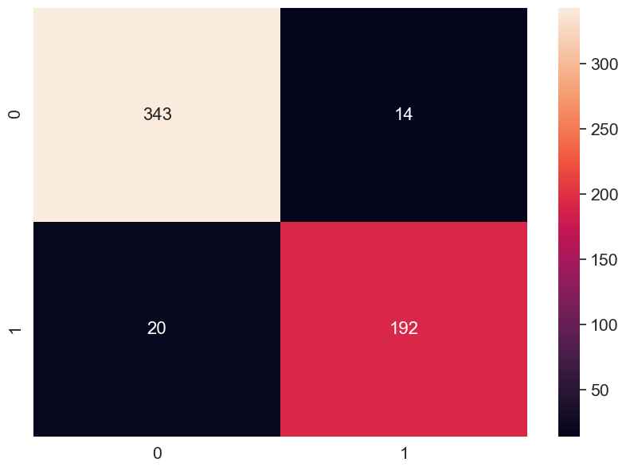

```python
plt.figure(figsize=(10,7))
sns.set(font_scale=1.4) # for label size
sns.heatmap(df_cm, annot=True, annot_kws={"size": 16}, fmt = 'g') # font size

plt.show()
```

#### Comment:

We can calculate the measures using the confusion matrix. You can find the measures below.

```python
true_neg = df_cm.iloc[0,0]
```

```python
true_pos = df_cm.iloc[1,1]
```

```python
false_neg = df_cm.iloc[1,0]
```

```python
false_pos = df_cm.iloc[0,1]
```

```python
measures = {"accuracy" : (true_pos + true_neg) / (true_pos + true_neg + false_pos + false_neg), "precision" : true_pos/(true_pos + false_pos), "recall" : true_pos/(true_pos + false_neg), "specificity":true_neg/(true_neg + false_pos)}
```

```python
measures
```

```
{'accuracy': 0.9402460456942003,
 'precision': 0.9320388349514563,
 'recall': 0.9056603773584906,
 'specificity': 0.9607843137254902}
```

#### Comment:

Let's try to predict the outcome of this model. If the probability is bigger than or equal to 0.5, the biopsy should be classified as malignant. Note that, this threshold might depend on the research for medical purposes, however we are only making an assumption here.

```python
y_pred = logit.predict(X)
```

```python
y_pred
```

```
0      0.999841
1      0.998986
2      0.999997
3      0.985750
4      0.999862
         ...
564    1.000000
565    0.999998
566    0.988669
567    1.000000
568    0.000057
Length: 569, dtype: float64
```

```python
y_pred_outcome =(logit.predict() >= 0.5).astype(int)
```

```python
y_pred_outcome
```

```
array([1, 1, 1, 1, 1, 1, 1, 1, 1, 1, 1, 1, 1, 1, 1, 1, 1, 1, 1, 0, 0, 0,
       1, 1, 1, 1, 1, 1, 1, 1, 1, 0, 1, 1, 1, 1, 1, 0, 1, 0, 0, 0, 1, 1,
       0, 1, 0, 1, 0, 0, 0, 0, 0, 1, 0, 0, 1, 1, 0, 0, 0, 0, 1, 0, 1, 1,
       0, 0, 0, 0, 1, 0, 1, 0, 0, 1, 0, 1, 1, 0, 0, 0, 1, 1, 0, 1, 1, 1,
       0, 1, 0, 1, 0, 0, 1, 1, 0, 0, 0, 1, 1, 0, 0, 0, 0, 1, 0, 0, 1, 0,
       0, 0, 1, 0, 0, 0, 0, 1, 1, 1, 0, 1, 1, 0, 0, 0, 0, 1, 1, 1, 0, 1,
       1, 0, 1, 0, 0, 0, 1, 0, 0, 1, 0, 0, 0, 0, 0, 0, 0, 0, 0, 0, 0, 0,
       0, 0, 1, 0, 0, 0, 0, 1, 1, 0, 1, 0, 0, 1, 1, 0, 0, 0, 1, 0, 0, 0,
       0, 1, 0, 0, 1, 1, 1, 0, 0, 0, 1, 0, 0, 0, 1, 0, 0, 1, 1, 0, 1, 1,
       1, 1, 0, 1, 1, 1, 0, 0, 0, 1, 0, 0, 1, 0, 1, 1, 1, 0, 0, 0, 1, 1,
       0, 0, 0, 1, 0, 0, 0, 0, 0, 1, 1, 0, 0, 1, 0, 0, 1, 1, 1, 1, 0, 0,
       0, 0, 1, 0, 0, 0, 0, 0, 1, 0, 1, 1, 1, 0, 1, 1, 1, 1, 1, 1, 1, 0,
       1, 1, 0, 0, 0, 0, 0, 0, 1, 0, 1, 1, 0, 1, 0, 0, 1, 0, 1, 1, 0, 0,
       0, 0, 0, 0, 1, 0, 0, 0, 0, 0, 0, 0, 0, 0, 1, 0, 1, 0, 0, 0, 0, 0,
       0, 0, 0, 0, 0, 0, 0, 0, 0, 1, 0, 0, 0, 1, 0, 1, 0, 0, 0, 0, 1, 1,
       1, 0, 0, 0, 0, 1, 0, 1, 0, 1, 0, 0, 0, 1, 0, 0, 0, 0, 0, 0, 0, 1,
       1, 1, 0, 0, 0, 0, 0, 0, 0, 0, 0, 1, 0, 1, 1, 0, 1, 1, 1, 0, 1, 1,
       0, 1, 0, 0, 0, 0, 0, 0, 0, 0, 0, 1, 0, 0, 0, 1, 0, 0, 1, 1, 0, 0,
       0, 0, 0, 0, 1, 0, 0, 0, 0, 0, 0, 0, 1, 0, 0, 0, 0, 0, 1, 0, 0, 1,
       0, 0, 0, 0, 0, 0, 0, 0, 0, 0, 0, 0, 1, 0, 1, 1, 0, 1, 0, 0, 0, 0,
       0, 1, 0, 0, 1, 0, 1, 0, 0, 1, 0, 1, 0, 0, 0, 1, 0, 0, 0, 0, 1, 1,
       0, 0, 0, 0, 0, 0, 1, 0, 0, 0, 0, 0, 0, 0, 0, 0, 0, 1, 0, 0, 0, 0,
       0, 0, 0, 1, 0, 0, 0, 0, 1, 0, 0, 1, 0, 0, 1, 1, 1, 1, 0, 1, 0, 0,
       0, 0, 0, 1, 0, 0, 1, 0, 0, 0, 1, 1, 0, 0, 0, 1, 0, 0, 0, 0, 0, 0,
       0, 0, 0, 0, 0, 1, 0, 1, 1, 1, 0, 0, 0, 1, 0, 0, 0, 0, 0, 0, 0, 0,
       0, 0, 0, 0, 0, 0, 0, 0, 0, 0, 1, 0, 1, 1, 1, 1, 1, 1, 0])
```

```python
confusion_matrix(y.astype(int),y_pred_outcome)
```

```
array([[343,  14],
       [ 20, 192]], dtype=int64)
```

```python
accuracy_score(y.astype(int), y_pred_outcome)
```

```
0.9402460456942003
```

```python
logit = LogisticRegression(solver = "liblinear")
print(classification_report(y.astype(int), y_pred_outcome))
```

```
              precision    recall  f1-score   support

           0       0.94      0.96      0.95       357
           1       0.93      0.91      0.92       212

    accuracy                           0.94       569
   macro avg       0.94      0.93      0.94       569
weighted avg       0.94      0.94      0.94       569
```

#### Comment:

As seen from the above results, our model seems good enough with high scores. Let's use Machine Learning to predict the outcome.

```python
from sklearn.model_selection import train_test_split
X_train, X_test, y_train, y_test= train_test_split(X, y, test_size = 0.2, random_state = 0)
```

```python
model = LogisticRegression(solver = "liblinear", C = 0.05, multi_class="ovr", random_state = 0)
```

```python
model.fit(X_train, y_train)
```

```
LogisticRegression(C=0.05, multi_class='ovr', random_state=0,
                   solver='liblinear')
```

```python
y_pred_new = model.predict(X_test)
```

```python
model.score(X_train, y_train)
```

```
0.8307692307692308
```

```python
model.score(X_test, y_test)
```

```
0.8245614035087719
```

#### Comment:

Let's see the confusion matrix and the report.

```python
conf_m = confusion_matrix(y_test, y_pred_new)
```

```python
conf_m
```

```
array([[62,  5],
       [15, 32]], dtype=int64)
```

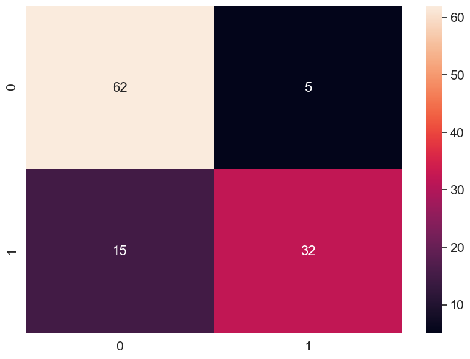

```python
df_conf_m = pd.DataFrame(conf_m, range(2), range(2))
plt.figure(figsize=(10,7))
sns.set(font_scale=1.4) # for label size
sns.heatmap(df_conf_m, annot=True, annot_kws={"size": 16}, fmt = 'g') # font size

plt.show()
```

```python
print(classification_report(y_test, y_pred_new))
```

```
              precision    recall  f1-score   support

           0       0.81      0.93      0.86        67
           1       0.86      0.68      0.76        47

    accuracy                           0.82       114
   macro avg       0.84      0.80      0.81       114
weighted avg       0.83      0.82      0.82       114
```

#### Comment:

Logistic Regression model is good enough to explain whether the biopsy in malignant or benign. \ The variables that are significant in determining the outcome are as follows:

- texture
- area
- smoothness
- concave points

### Cluster Analysis

Cluster analysis is useful when we want to classify the observations when they are homogenous within a group and heterogeneous between each other. For this part, we will examine Violent Crime Rates by US State in 1973 dataset provided by R. The data contains 50 observations and 4 variables which are:

- murder arrests (per 100,000)
- assault arrests (per 100,000)
- urban population
- rape arrests (per 100,000)

We will try to see whether the states can be grouped regarding the crime rates. Let's load the necessary packages.

```python
import scipy as sp
from sklearn.cluster import KMeans
```

```python
arrest = pd.read_csv("USArrest.csv")
```

```python
arrest.head()
```

|  | State | Murder | Assault | UrbanPop | Rape |
| --- | --- | --- | --- | --- | --- |
| 0 | Alabama | 13.2 | 236 | 58 | 21.2 |
| 1 | Alaska | 10.0 | 263 | 48 | 44.5 |
| 2 | Arizona | 8.1 | 294 | 80 | 31.0 |
| 3 | Arkansas | 8.8 | 190 | 50 | 19.5 |
| 4 | California | 9.0 | 276 | 91 | 40.6 |

```python
arrest.describe()
```

|  | Murder | Assault | UrbanPop | Rape |
| --- | --- | --- | --- | --- |
| count | 50.00000 | 50.000000 | 50.000000 | 50.000000 |
| mean | 7.78800 | 170.760000 | 65.540000 | 21.232000 |
| std | 4.35551 | 83.337661 | 14.474763 | 9.366385 |
| min | 0.80000 | 45.000000 | 32.000000 | 7.300000 |
| 25% | 4.07500 | 109.000000 | 54.500000 | 15.075000 |
| 50% | 7.25000 | 159.000000 | 66.000000 | 20.100000 |
| 75% | 11.25000 | 249.000000 | 77.750000 | 26.175000 |
| max | 17.40000 | 337.000000 | 91.000000 | 46.000000 |

```python
arrest.index = arrest.iloc[:,0]
arrest = arrest.iloc[:,1:5]
```

```python
arrest
```

| State | Murder | Assault | UrbanPop | Rape |
| --- | --- | --- | --- | --- |
| Alabama | 13.2 | 236 | 58 | 21.2 |
| Alaska | 10.0 | 263 | 48 | 44.5 |
| Arizona | 8.1 | 294 | 80 | 31.0 |
| Arkansas | 8.8 | 190 | 50 | 19.5 |
| California | 9.0 | 276 | 91 | 40.6 |
| Colorado | 7.9 | 204 | 78 | 38.7 |
| Connecticut | 3.3 | 110 | 77 | 11.1 |
| Delaware | 5.9 | 238 | 72 | 15.8 |
| Florida | 15.4 | 335 | 80 | 31.9 |
| Georgia | 17.4 | 211 | 60 | 25.8 |
| Hawaii | 5.3 | 46 | 83 | 20.2 |
| Idaho | 2.6 | 120 | 54 | 14.2 |
| Illinois | 10.4 | 249 | 83 | 24.0 |
| Indiana | 7.2 | 113 | 65 | 21.0 |
| Iowa | 2.2 | 56 | 57 | 11.3 |
| Kansas | 6.0 | 115 | 66 | 18.0 |
| Kentucky | 9.7 | 109 | 52 | 16.3 |
| Louisiana | 15.4 | 249 | 66 | 22.2 |
| Maine | 2.1 | 83 | 51 | 7.8 |
| Maryland | 11.3 | 300 | 67 | 27.8 |
| Massachusetts | 4.4 | 149 | 85 | 16.3 |
| Michigan | 12.1 | 255 | 74 | 35.1 |
| Minnesota | 2.7 | 72 | 66 | 14.9 |
| Mississippi | 16.1 | 259 | 44 | 17.1 |
| Missouri | 9.0 | 178 | 70 | 28.2 |
| Montana | 6.0 | 109 | 53 | 16.4 |
| Nebraska | 4.3 | 102 | 62 | 16.5 |
| Nevada | 12.2 | 252 | 81 | 46.0 |
| New Hampshire | 2.1 | 57 | 56 | 9.5 |
| New Jersey | 7.4 | 159 | 89 | 18.8 |
| New Mexico | 11.4 | 285 | 70 | 32.1 |
| New York | 11.1 | 254 | 86 | 26.1 |
| North Carolina | 13.0 | 337 | 45 | 16.1 |
| North Dakota | 0.8 | 45 | 44 | 7.3 |
| Ohio | 7.3 | 120 | 75 | 21.4 |
| Oklahoma | 6.6 | 151 | 68 | 20.0 |
| Oregon | 4.9 | 159 | 67 | 29.3 |
| Pennsylvania | 6.3 | 106 | 72 | 14.9 |
| Rhode Island | 3.4 | 174 | 87 | 8.3 |
| South Carolina | 14.4 | 279 | 48 | 22.5 |
| South Dakota | 3.8 | 86 | 45 | 12.8 |
| Tennessee | 13.2 | 188 | 59 | 26.9 |
| Texas | 12.7 | 201 | 80 | 25.5 |
| Utah | 3.2 | 120 | 80 | 22.9 |
| Vermont | 2.2 | 48 | 32 | 11.2 |
| Virginia | 8.5 | 156 | 63 | 20.7 |
| Washington | 4.0 | 145 | 73 | 26.2 |
| West Virginia | 5.7 | 81 | 39 | 9.3 |
| Wisconsin | 2.6 | 53 | 66 | 10.8 |
| Wyoming | 6.8 | 161 | 60 | 15.6 |

```python
kmeans = KMeans(n_clusters = 3) # k means clustering with 3 clusters
kmeans
```

```
KMeans(n_clusters=3)
```

```python
k_fit = kmeans.fit(arrest)
k_fit.labels_
```

```
array([0, 0, 0, 2, 0, 2, 1, 0, 0, 2, 1, 1, 0, 1, 1, 1, 1, 0, 1, 0, 2, 0,
       1, 0, 2, 1, 1, 0, 1, 2, 0, 0, 0, 1, 1, 2, 2, 1, 2, 0, 1, 2, 2, 1,
       1, 2, 2, 1, 1, 2])
```

```python
clusters = k_fit.labels_
```

```python
pd.DataFrame({"states": arrest.index, "clusters": clusters})
```

|  | states | clusters |
| --- | --- | --- |
| 0 | Alabama | 0 |
| 1 | Alaska | 0 |
| 2 | Arizona | 0 |
| 3 | Arkansas | 2 |
| 4 | California | 0 |
| 5 | Colorado | 2 |
| 6 | Connecticut | 1 |
| 7 | Delaware | 0 |
| 8 | Florida | 0 |
| 9 | Georgia | 2 |
| 10 | Hawaii | 1 |
| 11 | Idaho | 1 |
| 12 | Illinois | 0 |
| 13 | Indiana | 1 |
| 14 | Iowa | 1 |
| 15 | Kansas | 1 |
| 16 | Kentucky | 1 |
| 17 | Louisiana | 0 |
| 18 | Maine | 1 |
| 19 | Maryland | 0 |
| 20 | Massachusetts | 2 |
| 21 | Michigan | 0 |
| 22 | Minnesota | 1 |
| 23 | Mississippi | 0 |
| 24 | Missouri | 2 |
| 25 | Montana | 1 |
| 26 | Nebraska | 1 |
| 27 | Nevada | 0 |
| 28 | New Hampshire | 1 |
| 29 | New Jersey | 2 |
| 30 | New Mexico | 0 |
| 31 | New York | 0 |
| 32 | North Carolina | 0 |
| 33 | North Dakota | 1 |
| 34 | Ohio | 1 |
| 35 | Oklahoma | 2 |
| 36 | Oregon | 2 |
| 37 | Pennsylvania | 1 |
| 38 | Rhode Island | 2 |
| 39 | South Carolina | 0 |
| 40 | South Dakota | 1 |
| 41 | Tennessee | 2 |
| 42 | Texas | 2 |
| 43 | Utah | 1 |
| 44 | Vermont | 1 |
| 45 | Virginia | 2 |
| 46 | Washington | 2 |
| 47 | West Virginia | 1 |
| 48 | Wisconsin | 1 |
| 49 | Wyoming | 2 |

```python
from yellowbrick.cluster import KElbowVisualizer
```

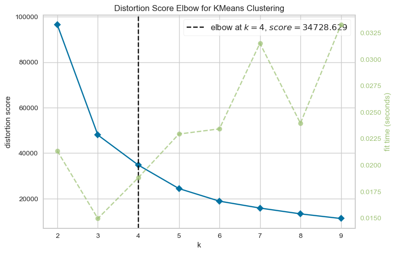

```python
kmeans = KMeans()
visualizer = KElbowVisualizer(kmeans, k=(2,10))
visualizer.fit(arrest)
visualizer.poof()                       # Elbow method minimizes within-cluster Sum of Square
```

#### Comment:

As the number of clusters increase, the variation within groups will decrease. The blue line shows variation within groups. According to the Elbow Method, we should choose k = 4 as the number of clusters.

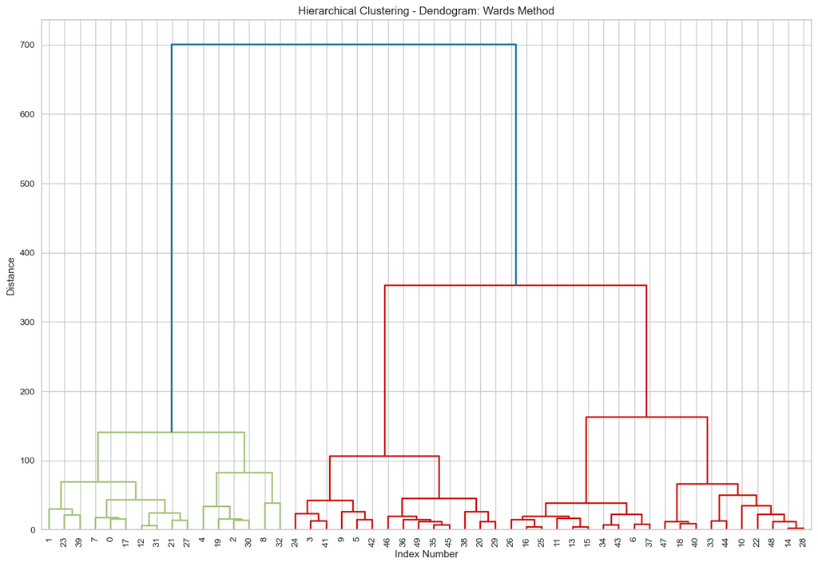

```python
from scipy.cluster.hierarchy import linkage
hc_complete = linkage(arrest, "complete")
hc_average = linkage(arrest, "average")
hc_single = linkage(arrest, "single")
hc_ward=linkage(arrest,"ward")

from scipy.cluster.hierarchy import dendrogram

plt.figure(figsize=(15, 10))
plt.title('Hierarchical Clustering - Dendogram: Wards Method')
plt.xlabel('Index Number')
plt.ylabel('Distance')
dendrogram( hc_ward, leaf_font_size=10)
plt.show()
```

#### Comment:

The dendogram above shows Ward's Method. We can obtain 3 to 5 clusters by cutting from distance between 100 and 200.

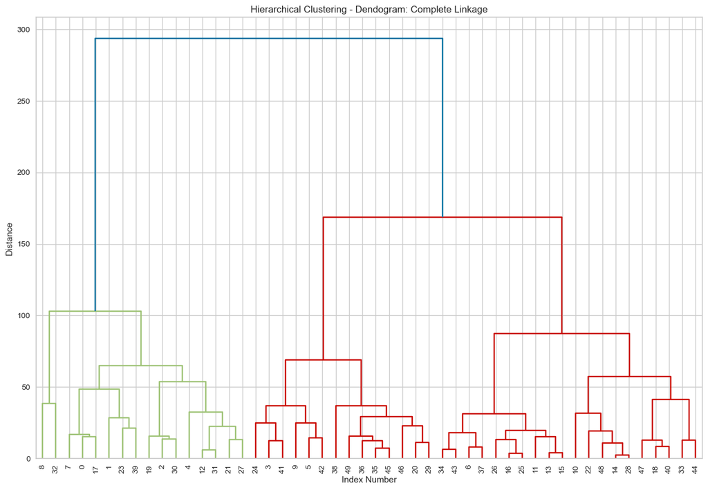

```python
plt.figure(figsize=(15, 10))
plt.title('Hierarchical Clustering - Dendogram: Complete Linkage')
plt.xlabel('Index Number')
plt.ylabel('Distance')
dendrogram(hc_complete, leaf_font_size=10)

plt.show()
```

#### Comment:

The dendogram above shows Complete Linkage Method. We can cut from distance near 100 and obtain 4 clusters or slightly above 100 and obtain 3.

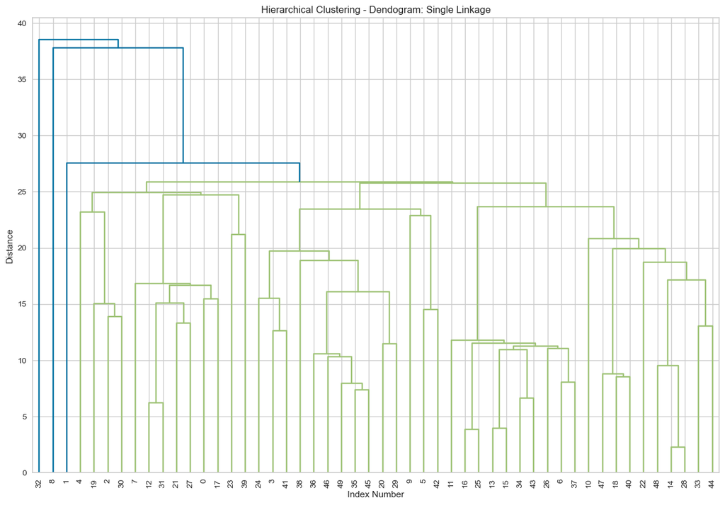

```python
plt.figure(figsize=(15, 10))
plt.title('Hierarchical Clustering - Dendogram: Single Linkage')
plt.xlabel('Index Number')
plt.ylabel('Distance')
dendrogram(hc_single, leaf_font_size=10)

plt.show()
```

#### Comment:

The dendogram above shows Single Linkage Method. Here, countries build up clusters as we have choose a larger distance, therefore we can cut from distance of 25-30 and obtain 3 to 6 clusters. It will not be useful if we want to lower the distance.

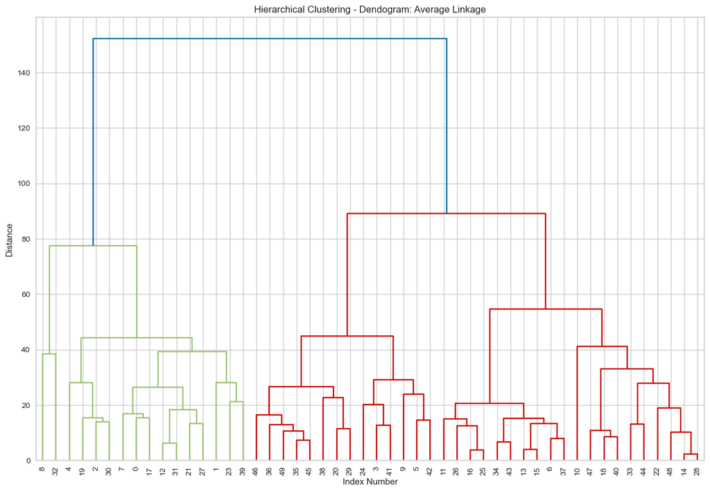

```python
plt.figure(figsize=(15, 10))
plt.title('Hierarchical Clustering - Dendogram: Average Linkage')
plt.xlabel('Index Number')
plt.ylabel('Distance')
dendrogram(hc_average, leaf_font_size=10)

plt.show()
```

#### Comment:

The dendogram above shows Average Linkage Method. We can cut from a distance of 60 to 80 and obtain 4 clusters.

### Factor Analysis

We have discussed the multicollinearity problem before and tried to solve it by dropping some of the variables or using Lasso & Ridge Regression. Here, we will use another method.  
The dataset that we use is a survey of customers regarding car pruchases. There are 90 observations and 14 variables, in which the variables take values of Likert scale from 1 to 5. The variables are as follows:

- Price
- Safety
- Exterior looks
- Space and comfort
- Technology
- After-sales service
- Resale value
- Fuel type
- Fuel efficiency
- Color
- Maintenance
- Test drive
- Product reviews
- Testimonials

Let's load our packages and data to begin the analysis.

```python
from factor_analyzer import FactorAnalyzer
from factor_analyzer.factor_analyzer import calculate_bartlett_sphericity
from factor_analyzer.factor_analyzer import calculate_kmo
```

```python
efa = pd.read_csv("EFA.csv")
```

```python
efa.head()
```

|  | Price | Safety | Exterior_Looks | Space_comfort | Technology | After_Sales_Service | Resale_Value | Fuel_Type | Fuel_Efficiency | Color | Maintenance | Test_drive | Product_reviews | Testimonials |
| --- | --- | --- | --- | --- | --- | --- | --- | --- | --- | --- | --- | --- | --- | --- |
| 0 | 4 | 4 | 5 | 4 | 3 | 4 | 5 | 4 | 4 | 2 | 4 | 2 | 4 | 3 |
| 1 | 3 | 5 | 3 | 3 | 4 | 4 | 3 | 4 | 3 | 4 | 3 | 2 | 2 | 2 |
| 2 | 4 | 4 | 3 | 4 | 5 | 5 | 5 | 4 | 5 | 4 | 5 | 4 | 4 | 3 |
| 3 | 4 | 4 | 4 | 3 | 3 | 4 | 5 | 5 | 4 | 4 | 4 | 2 | 5 | 3 |
| 4 | 5 | 5 | 4 | 4 | 5 | 4 | 5 | 3 | 4 | 5 | 5 | 5 | 5 | 2 |

```python
fa = FactorAnalyzer(
    n_factors=3,
    rotation='varimax',
    method='minres',
    use_smc=True,
    is_corr_matrix=False,
    bounds=(0.005, 1),
    impute='median',
    rotation_kwargs=None,)
```

```python
fa.fit(efa)
fa.loadings_
```

```
array([[ 0.475923  ,  0.14297535, -0.02528742],
       [-0.20345749,  0.28643516, -0.12168463],
       [-0.17960366,  0.16436185,  0.0328225 ],
       [-0.09232842,  0.81649739,  0.16843964],
       [ 0.05521508,  0.34270676,  0.10238212],
       [ 0.21057029,  0.46972469,  0.14939924],
       [ 0.67190512, -0.12369128, -0.11818926],
       [ 0.03759962,  0.56303743, -0.00925351],
       [ 0.56253075,  0.18156001,  0.3722802 ],
       [ 0.37262884, -0.13600939,  0.34068489],
       [ 0.65484325,  0.0559683 ,  0.1431362 ],
       [ 0.07012722,  0.16375809,  0.39405998],
       [ 0.30652785,  0.16474385,  0.40918499],
       [-0.26650519,  0.00284676,  0.69041952]])
```

#### Comment:

Here, loadings show the correlation between the variables and factors. \ ex: corr(v1,f1) = 0.475923

```python
fa.get_communalities()
```

```
array([0.2475841 , 0.1382472 , 0.06034961, 0.70356444, 0.13097873,
       0.28730127, 0.48072472, 0.31851051, 0.48799743, 0.273417  ,
       0.4524401 , 0.1870178 , 0.28853222, 0.54771223])
```

#### Comment:

Communalities show the explained part of each variable by the factors.  
ex: 24.75841% of the first variable is explained by the 3 factors.

```python
ev, v = fa.get_eigenvalues()
ev
```

```
array([2.75506068, 2.1640701 , 1.46454689, 1.32990296, 1.04029066,
       0.99198697, 0.80634535, 0.68102944, 0.60136568, 0.5536899 ,
       0.51364695, 0.46653069, 0.35660717, 0.27492656])
```

```python
chi_square_value, p_value = calculate_bartlett_sphericity(efa)
print(chi_square_value, p_value)
```

```
260.771089474057 8.93220098429307e-19
```

#### Comment:

Here, the p-value < 0.05, therefore significant. Bartlett value comes the first.

```python
kmo_all, kmo_model = calculate_kmo(efa)
print(kmo_model)
```

```
0.6091437123668768
```

#### Comment:

Kaiser-Mayer should be above 0.5. It shows that the factor analysis is appropriate.

```python
fa.get_factor_variance()
```

```
(array([1.86295338, 1.57513015, 1.16629384]),
 array([0.1330681, 0.1125093, 0.0833067]),
 array([0.1330681, 0.2455774, 0.3288841]))
```

#### Comment:

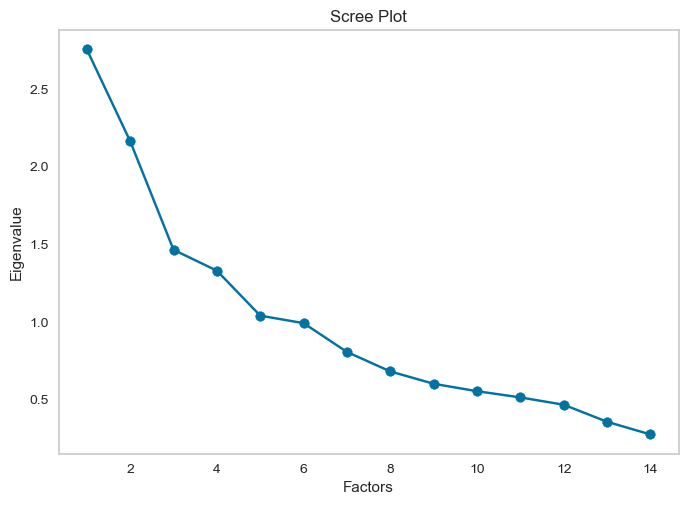

```python
# Create scree plot using matplotlib
plt.scatter(range(1,efa.shape[1]+1),ev)
plt.plot(range(1,efa.shape[1]+1),ev)
plt.title('Scree Plot')
plt.xlabel('Factors')
plt.ylabel('Eigenvalue')
plt.grid()
plt.show()
```

#### Comment:

After 3 factors, the Eigenvalues change slightly, as seen from the Scree Plot. We can cut from that point or depending on the tolerance level for our study.

```python
fa_scores=fa.transform (efa)      # factor scores
fa_scores = pd.DataFrame(fa_scores, columns=['Factor1', 'Factor2', 'Factor 3'])
print (fa_scores)
```

```
     Factor1   Factor2  Factor 3
0   0.256531 -0.071493 -1.059598
1  -0.787889 -0.943823 -1.965990
2   1.344663  0.256268 -0.130245
3   0.780155 -0.889219 -0.792694
4   1.493899 -0.019043 -0.668716
..       ...       ...       ...
85  0.595456 -0.169581  0.483747
86  0.062815 -0.210112  0.663176
87 -0.588147  0.045265 -0.130706
88 -0.327392 -0.085500  0.940424
89 -0.252985 -0.141560 -0.568170

[90 rows x 3 columns]
```

```python
efa_new = pd.concat([efa, fa_scores], axis = 1)
```

```python
efa_new
```

|  | Price | Safety | Exterior_Looks | Space_comfort | Technology | After_Sales_Service | Resale_Value | Fuel_Type | Fuel_Efficiency | Color | Maintenance | Test_drive | Product_reviews | Testimonials | Factor1 | Factor2 | Factor 3 |
| --- | --- | --- | --- | --- | --- | --- | --- | --- | --- | --- | --- | --- | --- | --- | --- | --- | --- |
| 0 | 4 | 4 | 5 | 4 | 3 | 4 | 5 | 4 | 4 | 2 | 4 | 2 | 4 | 3 | 0.256531 | -0.071493 | -1.059598 |
| 1 | 3 | 5 | 3 | 3 | 4 | 4 | 3 | 4 | 3 | 4 | 3 | 2 | 2 | 2 | -0.787889 | -0.943823 | -1.965990 |
| 2 | 4 | 4 | 3 | 4 | 5 | 5 | 5 | 4 | 5 | 4 | 5 | 4 | 4 | 3 | 1.344663 | 0.256268 | -0.130245 |
| 3 | 4 | 4 | 4 | 3 | 3 | 4 | 5 | 5 | 4 | 4 | 4 | 2 | 5 | 3 | 0.780155 | -0.889219 | -0.792694 |
| 4 | 5 | 5 | 4 | 4 | 5 | 4 | 5 | 3 | 4 | 5 | 5 | 5 | 5 | 2 | 1.493899 | -0.019043 | -0.668716 |
| ... | ... | ... | ... | ... | ... | ... | ... | ... | ... | ... | ... | ... | ... | ... | ... | ... | ... |
| 85 | 4 | 4 | 3 | 4 | 5 | 4 | 4 | 4 | 4 | 4 | 5 | 4 | 5 | 4 | 0.595456 | -0.169581 | 0.483747 |
| 86 | 4 | 3 | 4 | 4 | 5 | 4 | 3 | 4 | 4 | 5 | 4 | 4 | 5 | 4 | 0.062815 | -0.210112 | 0.663176 |
| 87 | 4 | 3 | 4 | 4 | 4 | 5 | 3 | 4 | 4 | 3 | 3 | 2 | 4 | 4 | -0.588147 | 0.045265 | -0.130706 |
| 88 | 4 | 4 | 3 | 4 | 4 | 5 | 3 | 4 | 4 | 4 | 4 | 4 | 4 | 5 | -0.327392 | -0.085500 | 0.940424 |
| 89 | 4 | 5 | 3 | 4 | 3 | 4 | 2 | 4 | 4 | 4 | 4 | 2 | 4 | 3 | -0.252985 | -0.141560 | -0.568170 |

90 rows × 17 columns

### Decision Trees

Decision tree is useful as a nonlinear classifier. They also have no assumptions about the dataset.  
Here, we're going to use some Machine Learning Algorithms. We will use Spam Email Database from kernlabs package of R. This dataset includes 4601 observations and 58 variables.

- The first variables measure the frequency of a variable name such as business in the email.
- Variables 49-54 incidate the frequency of the charachters other than letters such as exclamation mark.
- Variables 55 - 57 show measures regarding capital letters.
- Variable 58 indicates the type of mail as spam or nonspam.

Let's load necessary packages and observe our data.

```python
from sklearn.preprocessing import scale
from sklearn.model_selection import train_test_split, GridSearchCV, cross_val_score
from sklearn.metrics import confusion_matrix, accuracy_score, classification_report
from sklearn.metrics import roc_auc_score,roc_curve
from sklearn.neighbors import KNeighborsClassifier
from sklearn.discriminant_analysis import LinearDiscriminantAnalysis
from sklearn.linear_model import LogisticRegression
from sklearn.svm import SVC
from sklearn.naive_bayes import GaussianNB
from sklearn import tree
from sklearn.ensemble import RandomForestClassifier
from sklearn.ensemble import GradientBoostingClassifier
from xgboost import XGBClassifier
from lightgbm import LGBMClassifier
from catboost import CatBoostClassifier
```

```python
from sklearn.tree import DecisionTreeRegressor
from sklearn.ensemble import RandomForestRegressor
from sklearn.metrics import mean_squared_error
from sklearn.model_selection import GridSearchCV
from sklearn.metrics import roc_curve
#from mlxtend.feature_selection import ExhaustiveFeatureSelector as EFS
#from mlxtend.feature_selection import SequentialFeatureSelector as SFS
from sklearn.neighbors import KNeighborsRegressor
from sklearn.ensemble import BaggingClassifier
np.random.seed(0)
```

```python
spam = pd.read_csv("spam.csv")
```

```python
spam.head()
```

|  | Unnamed: 0 | make | address | all | num3d | our | over | remove | internet | order | ... | charSemicolon | charRoundbracket | charSquarebracket | charExclamation | charDollar | charHash | capitalAve | capitalLong | capitalTotal | type |
| --- | --- | --- | --- | --- | --- | --- | --- | --- | --- | --- | --- | --- | --- | --- | --- | --- | --- | --- | --- | --- | --- |
| 0 | 1 | 0.00 | 0.64 | 0.64 | 0.0 | 0.32 | 0.00 | 0.00 | 0.00 | 0.00 | ... | 0.00 | 0.000 | 0.0 | 0.778 | 0.000 | 0.000 | 3.756 | 61 | 278 | spam |
| 1 | 2 | 0.21 | 0.28 | 0.50 | 0.0 | 0.14 | 0.28 | 0.21 | 0.07 | 0.00 | ... | 0.00 | 0.132 | 0.0 | 0.372 | 0.180 | 0.048 | 5.114 | 101 | 1028 | spam |
| 2 | 3 | 0.06 | 0.00 | 0.71 | 0.0 | 1.23 | 0.19 | 0.19 | 0.12 | 0.64 | ... | 0.01 | 0.143 | 0.0 | 0.276 | 0.184 | 0.010 | 9.821 | 485 | 2259 | spam |
| 3 | 4 | 0.00 | 0.00 | 0.00 | 0.0 | 0.63 | 0.00 | 0.31 | 0.63 | 0.31 | ... | 0.00 | 0.137 | 0.0 | 0.137 | 0.000 | 0.000 | 3.537 | 40 | 191 | spam |
| 4 | 5 | 0.00 | 0.00 | 0.00 | 0.0 | 0.63 | 0.00 | 0.31 | 0.63 | 0.31 | ... | 0.00 | 0.135 | 0.0 | 0.135 | 0.000 | 0.000 | 3.537 | 40 | 191 | spam |

5 rows × 59 columns

```python
spam.drop("Unnamed: 0", inplace = True, axis = 1)
```

```python
spam.head()
```

|  | make | address | all | num3d | our | over | remove | internet | order | mail | ... | charSemicolon | charRoundbracket | charSquarebracket | charExclamation | charDollar | charHash | capitalAve | capitalLong | capitalTotal | type |
| --- | --- | --- | --- | --- | --- | --- | --- | --- | --- | --- | --- | --- | --- | --- | --- | --- | --- | --- | --- | --- | --- |
| 0 | 0.00 | 0.64 | 0.64 | 0.0 | 0.32 | 0.00 | 0.00 | 0.00 | 0.00 | 0.00 | ... | 0.00 | 0.000 | 0.0 | 0.778 | 0.000 | 0.000 | 3.756 | 61 | 278 | spam |
| 1 | 0.21 | 0.28 | 0.50 | 0.0 | 0.14 | 0.28 | 0.21 | 0.07 | 0.00 | 0.94 | ... | 0.00 | 0.132 | 0.0 | 0.372 | 0.180 | 0.048 | 5.114 | 101 | 1028 | spam |
| 2 | 0.06 | 0.00 | 0.71 | 0.0 | 1.23 | 0.19 | 0.19 | 0.12 | 0.64 | 0.25 | ... | 0.01 | 0.143 | 0.0 | 0.276 | 0.184 | 0.010 | 9.821 | 485 | 2259 | spam |
| 3 | 0.00 | 0.00 | 0.00 | 0.0 | 0.63 | 0.00 | 0.31 | 0.63 | 0.31 | 0.63 | ... | 0.00 | 0.137 | 0.0 | 0.137 | 0.000 | 0.000 | 3.537 | 40 | 191 | spam |
| 4 | 0.00 | 0.00 | 0.00 | 0.0 | 0.63 | 0.00 | 0.31 | 0.63 | 0.31 | 0.63 | ... | 0.00 | 0.135 | 0.0 | 0.135 | 0.000 | 0.000 | 3.537 | 40 | 191 | spam |

5 rows × 58 columns

### CART (Classification and Regression Tree)

#### Comment:

Split the data 80% for train and 20% for test.

```python
spam = spam.copy()
spam = spam.dropna()
y = spam["type"]
X = spam[["make","address","all","num3d","our","over","remove","internet","order","mail","receive","will","people","report","addresses","free","business","email","you","credit","your","font","num000","money","hp","hpl","george","num650","lab","labs","telnet","num857","data","num415","num85","technology","num1999","parts","pm","direct","cs","meeting","original","project","re","edu","table","conference","charSemicolon","charRoundbracket","charSquarebracket","charExclamation","charDollar","charHash","capitalAve","capitalLong","capitalTotal"]]

X_train, X_test, y_train, y_test = train_test_split(X, y,
                                                    test_size=0.20)
```

```python
from sklearn.tree import DecisionTreeClassifier
```

```python
cart = DecisionTreeClassifier()
cart_model = cart.fit(X_train, y_train)
```

```python
cart_model
```

```
DecisionTreeClassifier()
```

```python
y_pred = cart_model.predict(X_test)
accuracy_score(y_test, y_pred)
```

```
0.8979370249728555
```

#### Comment:

CART model correctly classifies 89.79% of the variables.

```python
cart_grid = {"max_depth": range(1,10),
            "min_samples_split" : list(range(2,50)) }
```

#### Comment:

Here, you need to determine a max depth value, which limits branching and therefore overfitting. I determined the range from 1 to 10.

```python
cart = tree.DecisionTreeClassifier()
cart_cv = GridSearchCV(cart, cart_grid, cv = 10, n_jobs = -1, verbose = 2)
cart_cv_model = cart_cv.fit(X_train, y_train)
```

```
Fitting 10 folds for each of 432 candidates, totalling 4320 fits
```

```python
print("best parameters: " + str(cart_cv_model.best_params_))
```

```
best parameters: {'max_depth': 9, 'min_samples_split': 2}
```

Here, 9 depth gives the optimum value for accuracy.

```python
cart = tree.DecisionTreeClassifier(max_depth = 3, min_samples_split = 26)
cart_tuned = cart.fit(X_train, y_train)
```

```python
y_pred = cart_tuned.predict(X_test)
accuracy_score(y_test, y_pred)
```

```
0.8773072747014115
```

```python
cart_tuned.feature_importances_
```

```
array([0.        , 0.        , 0.        , 0.        , 0.        ,
       0.        , 0.15740522, 0.        , 0.        , 0.        ,
       0.        , 0.        , 0.        , 0.        , 0.        ,
       0.05715301, 0.        , 0.        , 0.        , 0.        ,
       0.        , 0.        , 0.        , 0.        , 0.04878609,
       0.        , 0.0167572 , 0.        , 0.        , 0.        ,
       0.        , 0.        , 0.        , 0.        , 0.        ,
       0.        , 0.        , 0.        , 0.        , 0.        ,
       0.        , 0.        , 0.        , 0.        , 0.        ,
       0.        , 0.        , 0.        , 0.        , 0.        ,
       0.        , 0.51865771, 0.04480981, 0.        , 0.15643095,
       0.        , 0.        ])
```

```python
cart_tuned.feature_importances_.shape
```

```
(57,)
```

```python
spam.columns
```

```
Index(['make', 'address', 'all', 'num3d', 'our', 'over', 'remove', 'internet',
       'order', 'mail', 'receive', 'will', 'people', 'report', 'addresses',
       'free', 'business', 'email', 'you', 'credit', 'your', 'font', 'num000',
       'money', 'hp', 'hpl', 'george', 'num650', 'lab', 'labs', 'telnet',
       'num857', 'data', 'num415', 'num85', 'technology', 'num1999', 'parts',
       'pm', 'direct', 'cs', 'meeting', 'original', 'project', 're', 'edu',
       'table', 'conference', 'charSemicolon', 'charRoundbracket',
       'charSquarebracket', 'charExclamation', 'charDollar', 'charHash',
       'capitalAve', 'capitalLong', 'capitalTotal', 'type'],
      dtype='object')
```

```python
spam.shape
```

```
(4601, 58)
```

```python
features = {"Column Names": spam.columns[0:57], "Importance": cart_tuned.feature_importances_}
```

```python
feature_selection = pd.DataFrame(data = features)
```

```python
feature_selection
```

|  | Column Names | Importance |
| --- | --- | --- |
| 0 | make | 0.000000 |
| 1 | address | 0.000000 |
| 2 | all | 0.000000 |
| 3 | num3d | 0.000000 |
| 4 | our | 0.000000 |
| 5 | over | 0.000000 |
| 6 | remove | 0.157405 |
| 7 | internet | 0.000000 |
| 8 | order | 0.000000 |
| 9 | mail | 0.000000 |
| 10 | receive | 0.000000 |
| 11 | will | 0.000000 |
| 12 | people | 0.000000 |
| 13 | report | 0.000000 |
| 14 | addresses | 0.000000 |
| 15 | free | 0.057153 |
| 16 | business | 0.000000 |
| 17 | email | 0.000000 |
| 18 | you | 0.000000 |
| 19 | credit | 0.000000 |
| 20 | your | 0.000000 |
| 21 | font | 0.000000 |
| 22 | num000 | 0.000000 |
| 23 | money | 0.000000 |
| 24 | hp | 0.048786 |
| 25 | hpl | 0.000000 |
| 26 | george | 0.016757 |
| 27 | num650 | 0.000000 |
| 28 | lab | 0.000000 |
| 29 | labs | 0.000000 |
| 30 | telnet | 0.000000 |
| 31 | num857 | 0.000000 |
| 32 | data | 0.000000 |
| 33 | num415 | 0.000000 |
| 34 | num85 | 0.000000 |
| 35 | technology | 0.000000 |
| 36 | num1999 | 0.000000 |
| 37 | parts | 0.000000 |
| 38 | pm | 0.000000 |
| 39 | direct | 0.000000 |
| 40 | cs | 0.000000 |
| 41 | meeting | 0.000000 |
| 42 | original | 0.000000 |
| 43 | project | 0.000000 |
| 44 | re | 0.000000 |
| 45 | edu | 0.000000 |
| 46 | table | 0.000000 |
| 47 | conference | 0.000000 |
| 48 | charSemicolon | 0.000000 |
| 49 | charRoundbracket | 0.000000 |
| 50 | charSquarebracket | 0.000000 |
| 51 | charExclamation | 0.518658 |
| 52 | charDollar | 0.044810 |
| 53 | charHash | 0.000000 |
| 54 | capitalAve | 0.156431 |
| 55 | capitalLong | 0.000000 |
| 56 | capitalTotal | 0.000000 |

```python
CART_Feature = pd.DataFrame({"Importance": cart_tuned.feature_importances_*100},
                         index = spam.columns[0:57])
```

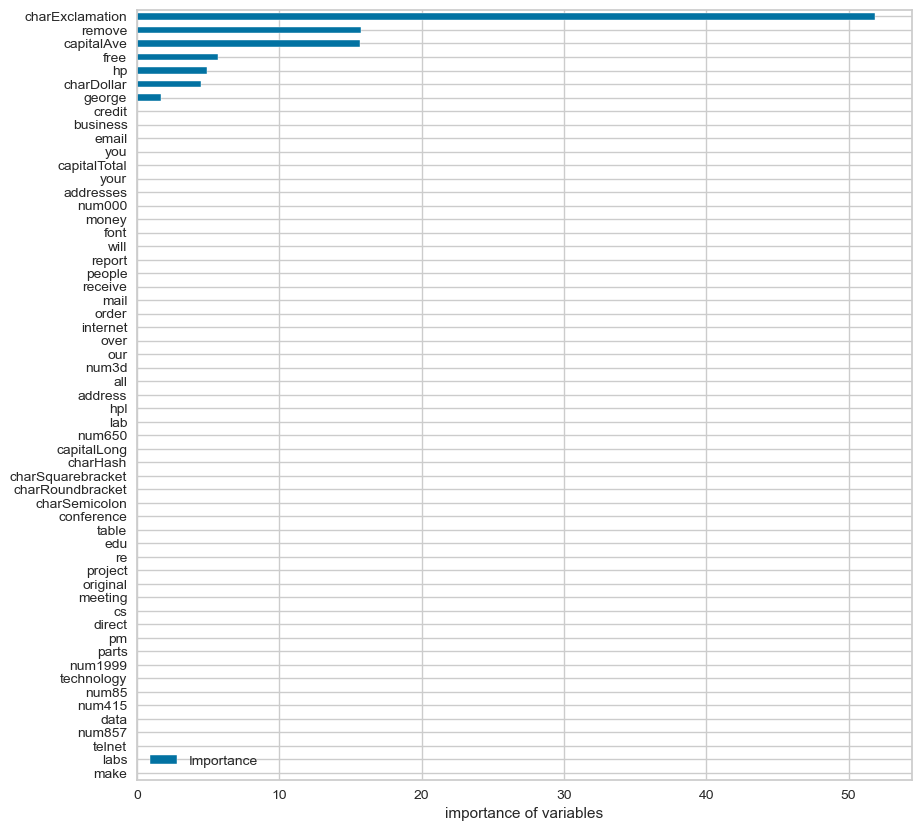

```python
CART_Feature.sort_values(by = "Importance",
                       axis = 0,
                       ascending = True).plot(kind ="barh", color = "b", figsize = (10,10))

plt.xlabel("importance of variables")
plt.show()
```

#### Comment:

The most important indicator of a mail adressed as spam is exclamation mark usage, as seen from the results.  
We can use:

- exclamation mark (!)
- word "remove"
- average # of capital letters
- word "free"
- word "hp"
- dollar sign ($)
- word "george"

to determine whether the mail is spam or not.

```python
text_representation = tree.export_text(cart_tuned)
print(text_representation)
```

```
|--- feature_51 <= 0.08
|   |--- feature_6 <= 0.04
|   |   |--- feature_52 <= 0.17
|   |   |   |--- class: nonspam
|   |   |--- feature_52 >  0.17
|   |   |   |--- class: spam
|   |--- feature_6 >  0.04
|   |   |--- feature_26 <= 0.08
|   |   |   |--- class: spam
|   |   |--- feature_26 >  0.08
|   |   |   |--- class: nonspam
|--- feature_51 >  0.08
|   |--- feature_54 <= 2.31
|   |   |--- feature_15 <= 0.30
|   |   |   |--- class: nonspam
|   |   |--- feature_15 >  0.30
|   |   |   |--- class: spam
|   |--- feature_54 >  2.31
|   |   |--- feature_24 <= 0.41
|   |   |   |--- class: spam
|   |   |--- feature_24 >  0.41
|   |   |   |--- class: nonspam
```

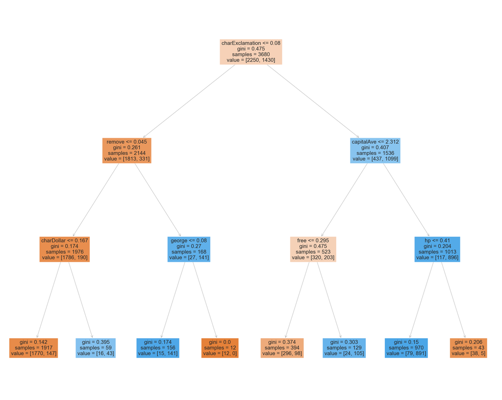

```python
from sklearn import tree
regressor = DecisionTreeClassifier(random_state = 0, max_depth=3)
regressor.fit(X_train, y_train)
fig = plt.figure(figsize=(25,20))
_ = tree.plot_tree(regressor, feature_names=["make","address","all","num3d","our","over","remove","internet","order","mail","receive","will","people","report","addresses","free","business","email","you","credit","your","font","num000","money","hp","hpl","george","num650","lab","labs","telnet","num857","data","num415","num85","technology","num1999","parts","pm","direct","cs","meeting","original","project","re","edu","table","conference","charSemicolon","charRoundbracket","charSquarebracket","charExclamation","charDollar","charHash","capitalAve","capitalLong","capitalTotal"], filled=True)
plt.show()
```

### Random Forest

Let's apply Random Forest as a decision tree algorithm.

```python
from sklearn.ensemble import RandomForestClassifier
```

```python
from sklearn import preprocessing
X_train = preprocessing.scale(X_train)
```

```python
rf_model = RandomForestClassifier().fit(X_train, y_train)
```

```python
rf_model
```

```
RandomForestClassifier()
```

```python
y_pred = rf_model.predict(X_test)
accuracy_score(y_test, y_pred)
```

```
0.6796959826275787
```

```python
rf_params = {"max_depth": [2,5,8,10],
            "max_features": [2,5,10],
            "n_estimators": [10,500,1000],
            "min_samples_split": [2,5,10]}
```

```python
rf_model = RandomForestClassifier()

rf_cv_model = GridSearchCV(rf_model,
                           rf_params,
                           cv = 10,
                           n_jobs = -1,
                           verbose = 2)
```

```python
rf_cv_model.fit(X_train, y_train)
```

```
Fitting 10 folds for each of 108 candidates, totalling 1080 fits
```

```
GridSearchCV(cv=10, estimator=RandomForestClassifier(), n_jobs=-1,
             param_grid={'max_depth': [2, 5, 8, 10], 'max_features': [2, 5, 10],
                         'min_samples_split': [2, 5, 10],
                         'n_estimators': [10, 500, 1000]},
             verbose=2)
```

```python
print("best pameters: " + str(rf_cv_model.best_params_))
```

```
best pameters: {'max_depth': 10, 'max_features': 5, 'min_samples_split': 5, 'n_estimators': 500}
```

#### Comment:

We can use these parameters to obtain the highest accuracy score.

```python
rf_tuned = RandomForestClassifier(max_depth = 10,
                                  max_features = 5,
                                  min_samples_split = 2,
                                  n_estimators = 500)

rf_tuned.fit(X_train, y_train)
```

```
RandomForestClassifier(max_depth=10, max_features=5, n_estimators=500)
```

```python
y_pred = rf_tuned.predict(X_test)
accuracy_score(y_test, y_pred)
```

```
0.6395222584147665
```

#### Comment:

Accuracy is lower compared to CART, therefore we might want to use CART instead of Random Forest for this model.  
Note that CART is less complex.

```python
Importance = pd.DataFrame({"Importance": rf_tuned.feature_importances_*100},
                         index = spam.columns[0:57])
```

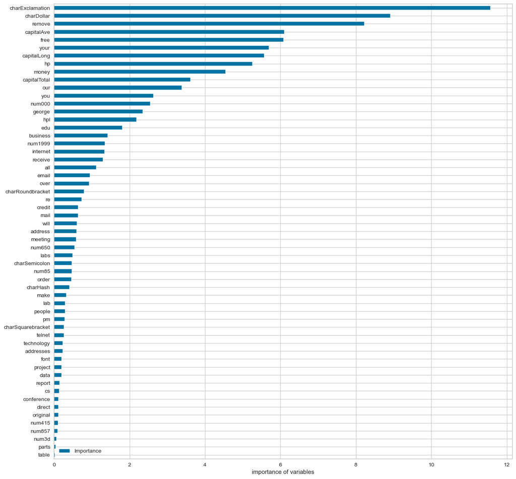

```python
Importance.sort_values(by = "Importance",
                       axis = 0,
                       ascending = True).plot(kind ="barh", color = "b", figsize = (15,15))

plt.xlabel("importance of variables")
plt.show()
```

#### Comment:

to determine whether the mail is spam or not according to Random Forest algorithm.

### References

[1] Ashutosh, (2017), MotorTrend Analysis, https://rpubs.com/aprasar/lm_mtcars  
[2] Brownlee, J., (2016), Machine Learning Datasets in R, https://machinelearningmastery.com/machine-learning-datasets-in-r/  
[3] UCI Machine Learning, (2016), https://www.kaggle.com/uciml/breast-cancer-wisconsin-data  
[4] R Documentation, Violent Crime Rates by US State, https://stat.ethz.ch/R-manual/R-patched/library/datasets/html/USArrests.html  
[5] Exploratory Factor Analysis in R, https://www.promptcloud.com/blog/exploratory-factor-analysis-in-r/  
[6] Anandu R, Email Spam Detection and Classification, https://rpubs.com/aquaregis32/spamEmailClassification_byAr32

### Data Resources

[1] Mtcars: https://gist.github.com/seankross/a412dfbd88b3db70b74b  
[2] Breast Cancer Wisconsin: https://archive.ics.uci.edu/ml/datasets/Breast+Cancer+Wisconsin+(Diagnostic)  
[3] Violent Crime Rates by US State, https://github.com/vincentarelbundock/Rdatasets/blob/master/csv/datasets/USArrests.csv  
[4] Car Purchase Survey, https://www.promptcloud.com/blog/exploratory-factor-analysis-in-r/  
[5] CRAN, Spam E-mail Database, https://search.r-project.org/CRAN/refmans/kernlab/html/spam.html